# Enhancing native freshwater crayfish habitat in invaded lake ecosystems

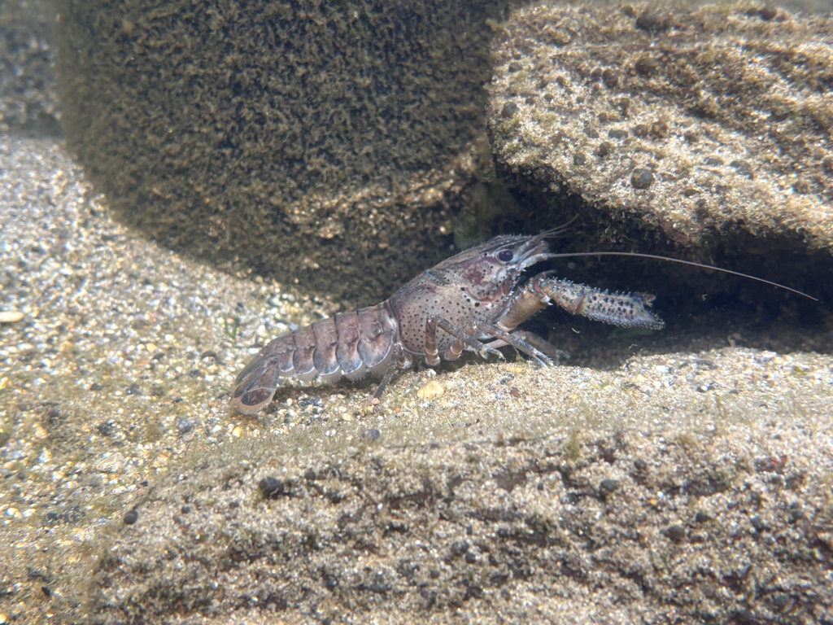

[output not shown]

# Enhancing native freshwater crayfish habitat in invaded lake ecosystems

A thesis submitted in partial fulfilment of the requirements  
for the degree of  
**Doctor of Philosophy**  
Te Aka Mātuatua — School of Science  
at  
**The University of Waikato**  
by  
**Olivier V. Raven**

[figure not shown]

2026

### Propositions

**From this thesis**

1. Structural complexity is essential for the recovery of kōura populations, when threatened by non native predator.
2. The fear of predators shapes prey behaviour as powerfully as predation itself, yet invasion biology rarely accounts for it.
3. Rock pile deployment is a viable and scalable tool for freshwater crayfish restoration in lakes, but success depends on location and design, not just presence.

**On science and publishing**

4. Freshwater crayfish play crucial roles in aquatic ecosystems but are often neglected.
5. The current methods of publishing and reviewing scientific research are locked into historical practices that are no longer suitable for today’s world.
6. Scientific knowledge is a public good. It should be openly accessible, transparently evaluated, and preserved in a way that keeps it useful and verifiable not just today, but across generations.

# Abstract

Native freshwater crayfish (*Paranephrops planifrons*, kōura) are a taonga (treasured) species in Aotearoa New Zealand with a rich history of harvest and trade by iwi (Māori communities). Over the past two decades, however, kōura populations have declined by up to 90 % in Lake Rotoiti (North Island, New Zealand), making traditional harvesting unviable. This decline is driven by degraded water quality, intensified lake stratification, and the spread of invasive fish and macrophytes. Since around 2016, the non-native brown bullhead catfish (*Ameiurus nebulosus*) has become established in the lake and preys on kōura, compounding the effects of other stressors. The decline in kōura, coupled with multiple threats, indicates that improving habitat is necessary for kōura population recovery. I hypothesised that habitat complexity is a key factor moderating predator-prey interactions, thus helping to prevent predation by non-native catfish, and that habitat enhancement interventions that increase rocky habitat would have positive impacts on kōura.

I conducted four complementary studies to investigate potential habitat enhancement tools: a behavioural controlled laboratory experiment examining refuge use in response to native and novel predators, a multi-lake field survey of shoreline habitat associations, a mesocosm study testing habitat structure configurations and materials, and a field deployment of stone pile habitats in Lake Rotoiti.

The results of the **laboratory experiment** revealed that kōura showed greater refuge use in the presence of the novel catfish than when exposed to the native predator, longfin eel (*Anguilla dieffenbachii*), highlighting the importance of refuge on predator-prey interactions.

The **field survey** assessed habitat conditions in five lakes using a structured study design and showed that complex shoreline habitats consisting of rocks and riparian vegetation were best predictors of kōura presence. This result helped establish the importance of rock habitat for extant kōura populations.

The **mesocosm experiment** evaluated the preference of kōura for materials that could be used to enhance their habitat. When hole sizes in habitat elements were held constant, kōura showed no preference between wood or stone, but more stable, heavier structures were preferred, and habitat configurations providing refuge heterogeneity showed broadest appeal across different size classes of kōura.

To evaluate the effects of adding rocky habitat in the littoral zones, I conducted a **field experiment** by placing stone piles at five separate locations in Lake Rotoiti. The study used a quasi-BACI design, collecting before-and-after data from control, addition and reference sites. The stone piles attracted kōura at densities similar to those in natural rocky habitat, demonstrating their potential to support kōura recovery. However, differences relative to bare control sites did not reach statistical significance after 18 months. A simulation-based power analysis suggested that longer monitoring periods are needed to detect population-level responses.

Together, these findings suggest that habitat complexity is a critical, actionable lever for kōura conservation, and that stone pile deployment offers a scalable, low-cost tool for restoring populations in degraded lake littoral zones. Beyond ecological value, these results provide practical evidence for restoration efforts that support kōura recovery, helping restore the traditional practices they have sustained for generations.

# Acknowledgements

> “The more we learn, the easier the human world becomes—but the natural world only grows more wondrous in its complexity”

First, I would like to express my deepest gratitude to the kōura (freshwater crayfish) and the giants on whose shoulders I stood to advance the study of kōura in Aotearoa New Zealand. In particular, I thank Alan Devcich, C. L. Hopkins, John Quinn, Stephanie Parkyn, Ian Kusabs, Brendan Hicks, John Hollows, Laura Francis, Grant Barnes, Ian Jowett, Karin Olsson, Per Nyström, Nisikawa Usio, Colin Townsend, and many others whose foundational work has shaped our understanding of this species. It has been a privilege to build upon their contributions and contribute to the conservation of kōura.

I am profoundly thankful to my supervisors, Deniz Özkundakci, Frank Burdon, Ian Kusabs, and Robin Holmes for their mentorship, quick reviewing processes, and unwavering support throughout this PhD journey. I also extend my appreciation to co-authors, Calum MacNeil and Finnbar Lee, for their collaboration and insights. This research would not have been possible without the support and collaboration of Te Arawa Lakes Trust and Te Komiti Whakahaere. I am especially grateful to Nicki Douglas, Soweeta Fort-D’ath, William Anaru (Te Arawa Lakes Trust), and Tihini Grant (Ngāti Pikiao)

My sincere thanks also extend to the Tāheke Opatia Marae, Te Takinga Marae, and landowners, Meryl Levon, Piripi Curtis, David McIlraith, Piki Thomas, Haddon Lock, Barnett Vercoe, Richard Vercoe, and Caroline Newton, for granting access to monitoring sites and facilitating fieldwork in Lake Rotoiti.

This research was made possible through funding from the Cawthron Institute’s Fish Futures programme, supported by a Ministry of Business, Innovation and Employment grant (CAWX2101). Thanks to Joanne Clapcott for incorporating this study into the Fish Futures programme, and to Ian Kusabs, who initiated the study and obtained the necessary iwi approvals and regional council consents that enabled the research to proceed. Additional funding was provided from the Bay of Plenty Regional Council under the Toihuarewa Waimāori - Bay of Plenty Regional Council Chair in Lake and Freshwater Science programme. I also acknowledge the contributions of Andy Bruere (BOPRC), Brendon Cappely (Greenfield Services Ltd), Joe Butterworth (JFB Enviro Ltd.), Cory O’Neill (Te Arawa Lakes Trust), Alex Simes (Te Arawa Lakes Trust), Martin Sarkezi (UoW), Mael Marguet (UoW), Ethan Morgan (UoW), Logan Kallam (UoW), Savio Dsouza (UoW), and Matt Prentice (UoW), whose assistance with fieldwork, data collection, and logistical support was indispensable. Special thanks to Dion and Josh for their friendship and help in constructing wood splits and blocks.

During my PhD, I became increasingly aware of the limitations of the current scientific publishing system, with paywalls restricting access, and a general lack of transparency in how research is evaluated and cited. This conviction that science should be open, accessible, and collaborative led me to found ScienceEcosystem.org, an open science platform working to lower barriers to knowledge sharing. I remain committed to developing it further in service of that goal.

### Use of Artificial Intelligence

Generative AI (Claude by Anthropic, primarily Sonnet models) was used during this research for the purpose of assistance with development of R code for data processing, analysis, and visualisation, with inputs including data structures, analysis objectives, and existing code. It also assisted by proof-reading of written sections, with inputs being draft text authored by the researcher. Code outputs were reviewed and validated against expected outputs and independently verified results. Writing suggestions were limited to grammar, sentence structure, and clarity, and were accepted or rejected at the author’s discretion; no text was generated by or copied from the tool. All analytical decisions, interpretations, and conclusions are the author’s own.

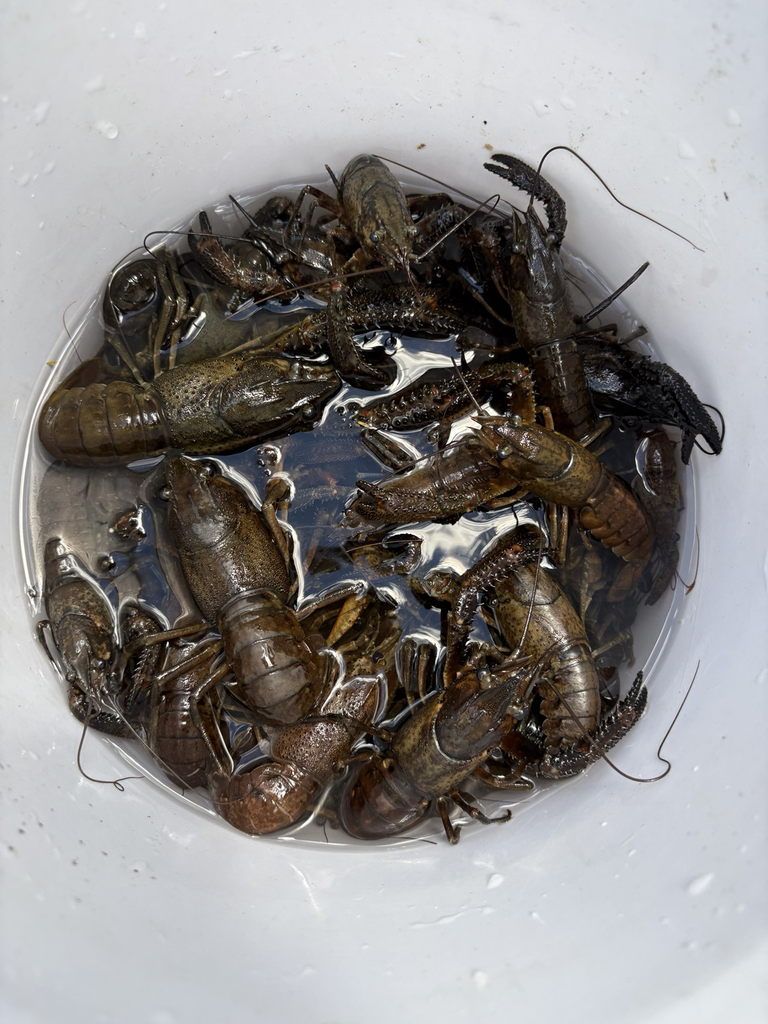

Chapter 1

# General Introduction

## Global freshwater ecosystem decline

Ecosystems worldwide are increasingly impacted by drivers of global change, with freshwater environments amongst the most degraded particularly from land-use activities, introduced species, and climate change (Harrison et al. 2018). This degradation is particularly concerning given that freshwater systems disproportionately support biodiversity and ecosystem services relative to their global area (Dudgeon et al. 2006). Among freshwater ecosystems, lakes are particularly sensitive to land-use pressures because they integrate inputs from their entire catchment, accumulating nutrients, sediment, and contaminants over time (Bhateria and Jain 2016).

Within lakes, the shallow littoral zone which is the productive interface between the terrestrial and aquatic system where stressors coverage most acutely (Strayer and Findlay 2010). Exposure to sunlight, enables photosynthesis in plants and algae, making the littoral zone one of the most productive and biodiverse areas in lakes (Vadeboncoeur et al. 2011; Geist and Hawkins 2016; Porst et al. 2019). In its shallow regions, emergent vegetation flourishes, creating essential nurseries for numerous species (Meerhoff and González-Sagrario 2022) and contributing significantly to the energy and nutrient cycling within lake food webs. Structurally complex areas in the littoral zone, including rocky habitats, can function as refugia, buffering multiple species against co-occurring threats, making their protection a conservation priority (Selwood and Zimmer 2020).

Despite this ecological importance, lake shorelines are often heavily impacted by human activities such as hardening, the introduction of invasive species, and pollution (Vadeboncoeur et al. 2002; Strayer and Findlay 2010). The effects of eutrophication and predation by non-native species in the littoral zone remain relatively understudied (Vander Zanden and Vadeboncoeur 2020). Reversing this degradation requires targeted interventions, which are often complex and resource-intensive (Palmer et al. 2005). This challenge has nonetheless driven recent global commitments to ecosystem restoration, including the reduction of nutrient inputs through buffer zones at lakes inlets and the rehabilitation of landscape connectivity (Meerhoff et al. 2022).

## Ecosystem and habitat restoration

Reversing widespread degradation of freshwater ecosystems, has prompted growing global investment in ecosystem and habitat restoration. The UN declared 2020-2030 the Decade for Ecosystem Restoration, with the goal of halting the degradation of ecosystems worldwide and made specific resolutions on sustainable lake management (UN. General Assembly 2019; Gann et al. 2019; United Nations Environment Programme 2022; Cooke et al. 2022). This commitment reflects a broader conservation imperative, as habitat degradation and loss remain key drivers of regional population extinction (Heinrichs et al. 2016).

Ecosystem restoration aims to recover an entire ecosystem, including its structure, function and dynamics, often with the goal of enhancing resilience to future stressors (Palmer and Ruhl 2015). Habitat restoration is a more targeted component of this broader goal, focusing on enhancing the quality or availability of habitat for a specific species or community, rather than an entire ecosystem (Miller and Hobbs 2007). Approaches to habitat restoration across terrestrial, coastal, and freshwater systems vary widely depending on the system and species involved, but commonly include replanting native vegetation, removing barriers like dams, or adding complexity to a habitat that has become simplified or degraded (Banks-Leite et al. 2020; Loch et al. 2020). The deliberate addition of hard substrate, such as boulders, large wood, gravel, or habitat unites, is one of the more direct and widely applied forms of habitat restoration, since many species depend on physical complexity for shelter, feeding or reproduction (Geist and Hawkins 2016).

Restoring structural complexity is comparatively well-established in marine systems, where artificial reefs are placed on the seafloor to rebuild complexity lost from degraded or removed natural reef habitat like coral and oyster reefs (Yanovski and Abelson 2019; Esquivel-Muelbert et al. 2026), supporting biodiversity recovery and fisheries productivity (Frehse et al. 2025). While artificial reefs are most often associated with marine environments, the same principle that adding physical structure to a degraded habitat can restore the complexity and shelter availability, extends to freshwater systems as well, including lentic environments such as lakes, where littoral zone habitat restoration remains comparatively underdeveloped (Geist and Hawkins 2016).

In freshwater environments, habitat restoration has been applied through the addition of habitat enhancement structures like, rocks, woody debris, or other natural substrates to streams and lakes that have lost structural complexity through historic modification, sedimentation, or substrate removal (Smokorowski and Pratt 2007; Roni et al. 2008; Parkyn et al. 2009). These additions have been used to support a range of freshwater taxa, including fish and invertebrates, by recreating the kind of structurally complex habitats that naturally support shelter, feeding and reproduction (Santos et al. 2011; McLean et al. 2015; Zhu et al. 2021). However, not all added structures achieve their intended benefit. Poorly designed or inappropriate materials, such as plastic habitat structures, can fail to replicate natural habitat function and risk becoming a form of littering rather than restoration (Baine 2001; Cooke et al. 2023), underscoring the importance of careful design when structures are used as a restoration tool. Within freshwater systems, structural restoration is particularly relevant for taxa that depend on physical complexity for shelter, including freshwater crayfish, which are ecologically important but undergoing severe declines globally (Richman et al. 2015).

## Freshwater crayfish: ecology and global decline

Freshwater crayfish are decapod crustaceans that form an important component of benthic macroinvertebrate communities in a wide range of freshwater ecosystems. They belong to the infraorder Astacidea, which is divided into two superfamilies: Astacoidea, restricted to the Northern Hemisphere, and Parastacoidea, restricted to the Southern Hemisphere (Crandall and De Grave 2017). The Astacoidea contains three families, Astacidae (western Eurasia and western North America), Cambaridae (eastern North America), and Cambaroididae (eastern Asia), while the Parastacoidea contains a single family, Parastacidae, with 15 genera distributed across Australia, New Zealand, New Guinea, South America, and Madagascar (Figure 1) (Crandall and De Grave 2017). Crayfish have a segmented exoskeleton with chelipeds (pincers) used for foraging, defence, and manipulating their environment. They are omnivorous, functioning as scavengers, predators, and prey within freshwater food webs (Momot 1995; Reynolds et al. 2013). Through burrowing, bioturbation, sediment reworking, macrophyte consumption, and the processing of organic matter, crayfish exert disproportionate effects on freshwater ecosystems (Nyström et al. 1996; Statzner et al. 2003; Creed and Reed 2004), making them important ecosystem engineers and keystone species (Crandall and Buhay 2008; Jones et al. 2016).

Despite their significant ecological role, 32 % of crayfish species worldwide are threatened with extinction (Richman et al. 2015) due to numerous threats, including habitat degradation, pollution, invasive species, and overexploitation. Among these invasive species, are a particularly pervasive and difficult to manage threat, as non-native fish and crayfish can, prey on native species, compete for habitat, and spread diseases (Danilović et al. 2022). For example, in Europe native crayfish such as *Astacus astacus*, *Austropotamobius pallipes*, and *A. torrentium* are threatened by the crayfish plague pathogen (*Aphanomyces astaci*, an oomycete), which is carried asymptomatically by many North American crayfish species (Holdich et al. 2009). These combined pressures mean that conservation of native crayfish requires not only an understanding of the threats they face, but also of the habitats they depend on, a challenge particularly acute for endemic species in geographically isolated systems such as those of Aotearoa New Zealand.

[figure not shown]

Figure 1: Global native distribution of freshwater crayfish families, following Crandall and De Grave (2017). Adapted from: (Fetzner 2019).

## Kōura: Aotearoa’s native freshwater crayfish

Aotearoa New Zealand’s (hereafter Aotearoa) native biota is disproportionately made up of endemic species because of its island biogeography and isolated location (Wallis and Trewick 2009). The two endemic species of freshwater crayfish found in Aotearoa are of the genus *Paranephrops*. These freshwater crayfish are also known by the Māori name kōura, although some iwi (Māori tribal groups) use other names including kēwai, kēkēwai, and koeke (Kusabs et al. 2018). The two species are the northern kōura (*Paranephrops planifrons* White, 1842) and the southern kōura (*P. zealandicus* [White, 1847]). The northern kōura can be found throughout the North Island and on the west side of the Southern Alps on the South Island (Figure 2). The southern kōura can be found on the eastern and southern part of the South Island and on Stewart Island.

[figure not shown]

Figure 2: Distribution of kōura (blue, left) and brown bullhead catfish (*Ameiurus nebulosus*, red, right), an introduced predator discussed in the following section, in Aotearoa New Zealand. Source: New Zealand Freshwater Fish Database (Stoffels 2024).

### Biology, ecology, and habitat use

Kōura inhabit a range of freshwater environments including streams, rivers and lakes and have been described as ecosystem engineers and keystone species in Aotearoa (Collier et al. 1997; Usio and Townsend 2004). They are associated with structurally complex habitats that provide physical shelter, preferring coarse gravel and rocky substrates in both streams and lakes (Jowett et al. 2008; Kusabs et al. 2015b). In streams, the highest abundances have been recorded on substrates with an average particle size of 130 mm (Olsson 2008; Jowett et al. 2008). Kōura avoid areas where dissolved oxygen levels drop below 5 mg/L and temperatures exceed 21 °C (Devcich 1979). Where suitable natural substrates are rare, kōura can excavate tunnels or burrows to provide cover, a behaviour documented in Lake Tikitapu, where the bottom sediment substrate permits burrowing (Pers. Comm. Ian Kusabs).

Kōura are nocturnal, retreating to deeper waters or physical shelters during the daylight hours to avoid predators, and emerging at night to forage, with some populations known to move in to the productive shallow zones of lakes (Devcich 1979). Kōura have direct development, meaning juveniles hatch as miniature adults with no free-living larval stage. Females carry eggs and newly hatched juveniles beneath the abdomen for approximately three weeks before release, typically at depths of less than 10 m in lakes (Parkyn and Kusabs 2007). Juveniles mature in two to three years depending on water temperature (Devcich 1979; Parkyn 2000).

### Cultural significance and population decline

[figure not shown]

Figure 3: Two versions of the tau kōura as it can be used for harvesting kōura in a lake. © Copyright Ian Kusabs.

[figure not shown]

Figure 4: Kōura catches in CPUE in Lake Rotoiti at the Ōkere inlet between 2005 and 2024. Kōura were caught using the tau kōura. The dashed vertical line indicates first confirmed catfish detection in Lake Rotoiti (2016). Adapted from (Kusabs et al. 2026).

## Brown bullhead catfish: a novel predator in Aotearoa lakes

The brown bullhead catfish (*Ameiurus nebulosus* [Lesueur, 1819], hereafter catfish) is native to North America but has been introduced worldwide for aquaculture and as a game fish, contributing to profound ecological and economic disruption that biological invasions cause globally (Haubrock et al. 2025). In Aotearoa, 140 individuals were introduced in 1877 to Lake St John (Lake Waiatarua) in the Auckland region, reportedly by mistake, as the intended species was the channel catfish (*Ictalurus punctatus* (Rafinesque, 1818)) (Barnes 1996). Although Lake St John has since been drained, catfish persisted and have spread throughout the upper North Island via accidental and deliberate releases (Figure 2). Lake Taupō was first invaded in 1985 following an illegal release (Barnes 1996). In the Rotorua Te Arawa Lakes, a dead catfish was found at Okawa Bay in Lake Rotoiti in 2009 (Blair and Hicks 2009) and sightings followed in 2014, but surveys failed to detect catfish until 2016, when multiple individuals were found at the western end of Lake Rotoiti, including Te Weta Bay where catfish were recovered during macrophyte harvesting operations (Francis 2019). Catfish subsequently spread to Lake Rotorua in 2018 via the Ōhau Channel. Since 2016, routine monitoring and active control fishing have been carried out to reduce their impact (Grayling 2020).

Catfish are physiologically tolerant of a wide range of conditions, including elevated temperatures and low dissolved oxygen (Scott and Crossman 1973); this resilience allows them to persist under stressors that increasingly impact native species (Lee et al. 2025). They are omnivorous benthic feeders, with individuals reaching 200-455 mm in length and living up to eight years (Barnes 1996). Their diet overlaps with, and partly consists of, native species leading to both competition and direct predation (Figure 5) (Scott and Crossman 1973; Dedual 2019).

Catfish are known predators of kōura and have contributed to declining kōura CPUE in Lakes Rotorua and Rotoiti (Kusabs et al. 2026). While kōura abundance had been declining before catfish establishment, the decline became less variable after 2016, with fewer recovery periods, suggesting catfish have reduced the population’s capacity to rebound (Kusabs et al. 2026). Catfish habitat use varies seasonally: in lakes, catfish occupy depths down to approximately 17 m (Dedual 2002) and shift between weedy and rocky habitats depending on the season, primarily rocky habitats in winter when macrophytes die back, and both habitat types during autumn and spring (Barnes 1996; Barnes and Hicks 2003). Spawning occurs in nests excavated in mud or sand, typically in shallow areas near rocks or submerged tree trunks for protection (Scott and Crossman 1973). Nests are roughly the size of the female, who may carry between 2,000 and 13,000 eggs depending on body size (Scott and Crossman 1973). Acoustic tagging of catfish in Lake Rotoiti confirmed these seasonal patterns: catfish concentrated in nearshore shallows during spring and summer, likely seeking warmer water for feeding and reproduction, before dispersing to mid-water offshore habitats in winter, consistent with earlier reports of maximum depths around 17 m (Dedual 2002), rarely exceeding 15 m depth even when the lake is considerably deeper (Blanchfield et al. 2026).

Critically, Aotearoa lacks native Siluriformes, meaning kōura and other native fauna have no evolutionary history with catfish and may therefore fail to recognise them as a predator, a phenomenon termed predator naiveté (Sih et al. 2010; Carthey and Banks 2014). Predator naiveté can leave prey populations particularly vulnerable because effective antipredator responses are often shaped by prior exposure over evolutionary time (Sih et al. 2010). However, prey may alternatively respond with generalised fear toward any novel or unfamiliar stimulus, producing exaggerated antipredator behaviour regardless of actual threat level (Sih et al. 2023). Beyond direct consumption, predator presence alone can alter prey behaviour by increasing refuge use, decreasing movement and suppressing foraging. These non-consumptive effects (NCEs) can lead to reduced growth and reproduction (Preisser and Bolnick 2008). The availability of physical refugia is central to mediating these effects as structurally complex habitats allow prey to shelter from predation risk while retaining access to foraging opportunities (Selwood and Zimmer 2020). Restoring structural habitat may therefore buffer the non-consumptive effects of living alongside a novel predator.

[figure not shown]

Figure 5: Dissection of a catfish from Lake Rotoiti revealed kōura remains (tail) and smelt in its stomach. As smelt are pelagic and unlikely to be caught by catfish in open water, some prey items, including potentially the kōura, may have been consumed while both species were co-trapped in the fyke net rather than through active predation in the lake.

## Study system: the Rotorua Te Arawa Lakes

This research was conducted in the Rotorua Te Arawa Lakes, a group of twelve volcanic lakes in the central North Island of Aotearoa (Bay of Plenty region; Figure 6; Table 1). The lakes were formed by rhyolitic volcanic activity over the past ~230,000 years and continue to experience volcanic influence, most recently through the 1886 eruption of Mount Tarawera, which deposited basalt scoria and the distinctive Rotomāhana Mud across the surrounding catchments (Cole et al. 2014). The lakes vary considerably in size (0.3–81 km²) and maximum depth (13.5–125 m), and span a gradient of mixing regimes and trophic states from oligotrophic (e.g. Tarawera, Rotomā) to eutrophic (e.g. Rotorua, Ōkaro; Table 1). This diversity makes the Te Arawa Lakes a particularly informative system for studying how kōura respond to differing combinations of habitat structure, water quality, and predator presence.

[interactive chart not shown]

Figure 6: Rotorua Te Arawa Lakes trophic state map. Colours show trophic state per year (2008–2022) derived from LAWA TLI data — use the year slider to explore change over time. Click a lake for TLI details. Data sourced from: (LAWA 2025).

Table 1: Physical and limnological characteristics of the twelve Rotorua Te Arawa Lakes. Data sourced from: LAWA (2025). Lakes Rotorua and Rotoiti have established catfish populations and Lakes Ōkaro and Rotomāhana have no kōura populations.

| Lake name | Surface area (km²) | Perimeter length (km) | Catchment area (km²) | Mean depth (m) | Max depth (m) | Depth ratio | Elevation (m) | Mixing regime | Trophic state |
| --- | --- | --- | --- | --- | --- | --- | --- | --- | --- |
| Rotorua | 81 | 45 | 508 | 11 | 45 | 0.24 | 280 | Polymictic | Eutrophic |
| Rotoiti | 34 | 61 | 123.7 | 31.5 | 124 | 0.25 | 279 | Monomictic | Mesotrophic |
| Rotoehu | 8 | 40 | 49.2 | 8 | 13.5 | 0.59 | 295 | Polymictic | Eutrophic |
| Rotomā | 11 | 24 | 27.8 | 36.9 | 83 | 0.44 | 316 | Monomictic | Oligotrophic |
| Ōkataina | 11 | 29 | 59.8 | 39.4 | 78.5 | 0.5 | 305 | Monomictic | Oligotrophic |
| Ōkāreka | 3 | 11 | 19.6 | 20 | 33.5 | 0.6 | 355 | Monomictic | Mesotrophic |
| Tikitapu | 1 | 5 | 6.2 | 18 | 27.5 | 0.65 | 355 | Monomictic | Oligotrophic |
| Rotokākahi | 4 | 16 | 18.7 | 17.5 | 32 | 0.55 | 395 | Monomictic | Mesotrophic |
| Tarawera | 41 | 48 | 143.1 | 50 | 87.5 | 0.57 | 305 | Monomictic | Oligotrophic |
| Rotomāhana | 9 | 27 | 83.3 | 60 | 125 | 0.48 | 340 | Monomictic | Mesotrophic |

[output cut: 2 more lines]

The lake beds are owned by the Te Arawa Lakes Trust (TALT), with the exception of Lake Rotokākahi, which remains under the guardianship of Tuhourangi and Ngāti Tumatawera iwi. TALT, in collaboration with Te Komiti Whakahaere, oversees the harvest of ngā taonga in the Te Arawa Lakes under a mahere whakahaere (Fisheries Management Plan; Te Arawa Lakes Trust (2015)), reflecting the deep cultural and ecological significance of the lakes to Te Arawa iwi and hapū.

Each lake supports a mix of native and introduced species. Alongside kōura and catfish discussed above, native taxa include the freshwater mussel kākahi (*Echyridella menziesii*), kōaro (*Galaxias brevipinnis*), bullies (toitoi; *Gobiomorphus cotidianus*), longfin eel (tuna; *Anguilla dieffenbachii*), and common smelt (*Retropinna retropinna*). Introduced species include brown and rainbow trout (*Salmo trutta*, *Oncorhynchus mykiss*), mosquitofish (*Gambusia affinis*), and goldfish (morihana; *Carassius auratus*). The lakes also support a mix of native macrophytes and several invasive species that have transformed the littoral zone in many lakes (Figure 7) (Burton 2017). Current lake management prioritises improving water quality and controlling invasive species. This includes alum dosing (aluminium sulphate) in Lakes Rotorua and Ōkaro to reduce phosphorus loading, mechanical and chemical control of invasive macrophytes, and the community-led “Catfish Killas” programme, which aims to reduce catfish abundance from the lakes.

[figure not shown]

Figure 7: Photo of some of the native and non-native macrophyte species found in Lake Rotoiti.

## Compounding threats to kōura habitat

In addition to predation by catfish, kōura face multiple interacting stressors that progressively restrict the habitat available to them (Kusabs et al. 2015a; Lee et al. 2025). Kōura use rocky habitats or deeper parts of the lake which provides refuge from predators during the day (Jowett et al. 2008; Kusabs et al. 2015b) and at night, kōura migrate vertically into the productive littoral zone to forage (Devcich 1979). The use of both shallow and deep habitats means that, for kōura to thrive, both must remain accessible and habitable.

The importance of an oxygenated deep refuge is illustrated by Lake Taupō (maximum depth 186 m), where catfish and kōura demonstrate a more stable co-existence because deep waters remain oxygenated below the thermocline year-round (Verburg and Albert 2019), providing continuous suitable habitat for kōura (Kusabs and Taiaroa 2015). In Lake Rotoiti, this deep refuge becomes anoxic and unavailable for kōura (Kusabs et al. 2026).

Climate change is expected to intensify all of these pressures. Stronger and longer thermal stratification will expand and prolong anoxic conditions below the thermocline (Woolway et al. 2021), while warming surface waters are projected to expand the range of suitable catfish habitat in Aotearoa (Lee et al. 2025). The compression of suitable kōura habitat documented here is therefore likely to accelerate, reinforcing the need to understand which habitats kōura prefer and whether habitat enhancement can build resilience in kōura populations. This rationale is supported by evidence from other systems supporting crayfish: in lakes where muddy substrates provide limited refugia, adding rocky substrate has been shown to relax refugia limitation and increase noble crayfish (*Astacus astacus*) population density (Johnsen and Taugbøl 2008). Structural addition can only deliver this benefit when water quality falls within species tolerance, as when dissolved oxygen or temperature exceeds physiological limits, species cannot persist regardless of refuge quality.

[interactive chart not shown]

Figure 8: Liveable habitat (%) for kōura across eleven of the Rotorua Te Arawa Lakes from 2003 to 2026, by season. Hover a line to see exact values. Liveable habitat is the proportion of lake bottom area meeting dissolved oxygen (> 5 mg/L) and temperature (< 21 °C) thresholds. Data: BOPRC CTD casts + LimnoTrack buoy (Moore and McBride 2026).

[interactive chart not shown]

Figure 9: Long-term trends in seasonal liveable habitat for kōura across eleven Rotorua Te Arawa Lakes. Hover points for lake, season, year and value. Lines are linear regressions with 95% confidence intervals. Data: BOPRC CTD casts + LimnoTrack buoy (Moore and McBride 2026).

[interactive chart not shown]

Figure 10: Spatial liveable habitat across the Rotorua Te Arawa Lakes. Use the layer control (top right) to switch between the long-term trend (red = declining, blue = improving) and seasonal persistence (proportion of observed periods each location was liveable). Zoom and pan to explore individual lakes.

## Knowledge gaps and thesis aims

The previous sections established that kōura populations in the Rotorua Te Arawa Lakes are declining because of multiple interacting pressures, such as invasive predation, eutrophication, thermal stratification, and macrophyte expansion. It was also shown that their suitable habitat is both seasonally compressed and progressively shrinking (Kusabs et al. 2026). Although the broad drivers of decline are increasingly well understood, several critical knowledge gaps limit our ability to design effective interventions, particularly around how kōura interact behaviourally with catfish as a novel predator, and around the role of habitat structure and refugia in mediating those predator-prey interactions, questions relevant to freshwater prey species facing novel predators globally.

First, while catfish are implicated as a key driver of kōura decline, the effect catfish have on kōura behaviour leading to non-consumptive effects in comparison with native predators had not been quantified. I therefore conducted aquarium experiments in which kōura refuge use was recorded when exposed to native longfin eels and to catfish. I expected that kōura would show no response to catfish consistent with predator naïveté (Sih et al. 2010), or that they would show stronger antipredator responses to the novel catfish than to native eels, consistent with generalised fear response (Sih et al. 2023).

Second, the natural habitats that kōura prefer had been described in streams and deeper parts of lakes but which shoreline habitat features kōura prefer remained unknown. I therefore monitored kōura presence at 60 shoreline sites across five of the Rotorua Te Arawa Lakes, recording habitat features and fish species. I expected that rocky substrates with high structural complexity would be the primary predictor of kōura presence, consistent with stream habitat studies (Olsson 2008; Jowett et al. 2008).

Third, although the deployment of habitat enhancement structures had been applied in freshwater systems globally to support fish and invertebrates (Smokorowski and Pratt 2007; Santos et al. 2011), few studies had tested which combinations of material and structural configuration best support crayfish specifically. I therefore designed and tested multiple shelters configurations using wood and stone in mesocosm experiments. I expected that configurations providing multiple crevices of varying sizes would be preferred by the widest range of kōura, including juveniles.

Finally, no field deployments of habitat enhancement structures for kōura in lakes had previously been reported. Therefore, I deployed stone piles in Lake Rotoiti and expected that kōura populations at the stone piles would increase, as providing more refuge habitat would allow more kōura to avoid predators. A secondary aim of the final study was to identify potential unintended consequences of habitat enhancement, including the risk that structures may provide refuge for catfish.

This thesis addresses each of these gaps in turn through four research chapters, building from behavioural mechanisms in controlled conditions, through natural habitat use, to structure design, and finally to field deployment.

## Research questions and thesis structure

This thesis pursued two complementary sets of aims. The first was to advance fundamental ecological knowledge about how a naïve prey species responds behaviourally to a novel predator, and about the role of habitat structure in mediating predator-prey interactions, questions with global relevance to freshwater systems facing invasive species. The second was applied: to identify optimal strategies for restoring and enhancing kōura populations in the Rotorua Te Arawa Lakes through structural habitat enhancement. The findings of this thesis are reported in the following four research chapters, followed by a synthesis and a general conclusion (Table 2).

Table 2: Research questions addressed in each thesis chapter.

| RQ | Chapter | Research question |
| --- | --- | --- |
| 1 | 2 — Native vs. Novel Threats | How do native and non-native predators differentially influence antipredator behaviour and refuge use in kōura? |
| 2 | 3 — Where do Kōura Live? | Which natural shoreline features do kōura prefer? |
| 3 | 4 — The Importance of Structure | Does shelter structure or material composition drive kōura refuge selection? |
| 4 | 5 — Rock Piles as Kōura Habitat | Can habitat enhancement structures provide effective habitat for kōura in Lake Rotoiti? |

Before the deployment of any structures, it was first necessary to understand the response of kōura when exposed to native and novel predators. Therefore, in **Chapter 2**, kōura were exposed to native eels and to novel catfish in an aquarium study where refuge use was analysed. In **Chapter 3**, the natural preferred shoreline habitat for kōura was investigated by monitoring 60 sites over five lakes. From this we gained a clearer picture of which habitat features support kōura and which shoreline areas would most benefit from structural enhancement. In the next chapter, **Chapter 4**, we designed and tested shelter types to determine kōura preference. Kōura are known to use various materials and compositions, so for this study we tested different configurations of wood and stone structures in mesocosm experiments to determine kōura shelter preferences. With an optimal design identified, **Chapter 5** deployed five stone pile structures along the shoreline in Lake Rotoiti and monitored kōura colonisation and abundance development over 18 months. **Chapter 6** synthesises the findings across all four research chapters, incorporating two pilot case studies: a stone pile deployment in Lake Ōkaro where water quality and kōura reintroduction were monitored, and a deeper-water deployment across a depth gradient in Lake Rotoiti assessed using Remotely Operated Vehicle (ROV) surveys. The chapter concludes with an overview of the findings and considers how structural habitat enhancement can contribute to building resilience in declining freshwater crayfish populations more broadly. As each of the four research chapters are written as stand-alone manuscripts, some overlap of background information and methods is unavoidable. However, the general introduction provides a comprehensive overview of the study system, the species involved, and the research questions addressed in this thesis.

Chapter 2

# Chapter 2 Native vs. Novel Threats

## Abstract

The non-consumptive effects (NCEs) of predators on prey result in costly antipredator behaviours, including increased refuge use and reduced foraging. NCEs significantly influence prey population dynamics, community interactions, and affect ecosystem functioning, particularly when the prey are keystone species. In Aotearoa-New Zealand, the native freshwater crayfish kōura (*Paranephrops planifrons*) is a keystone species with an important functional role affecting sediment bioturbation, nutrient cycling, and benthic community structure. Kōura are preyed upon by multiple predators including native longfin eel (*Anguilla dieffenbachii*) and invasive brown bullhead catfish (*Ameiurus nebulosus*). Under laboratory conditions, we tested whether visual and chemical cues from these two predators induced different refuge-seeking and feeding behaviour responses by kōura. Predator presence produced in the dark a NCE on refuge use, with kōura exposed to catfish showing significantly greater refuge-seeking behaviour than those exposed to eels. This result is consistent with the generalisation theory triggered by unfamiliar predator cues rather than classic prey naivety. Our study indicates catfish incursions may provoke a greater NCE on kōura behaviours than resident eels. As catfish range expansion continues, these NCEs may represent an ecologically significant and underappreciated threat to kōura populations, compounding the direct predation pressure already documented for this invader.

## Introduction

Biological invasions can have profound impacts on invaded ecosystems, particularly through the introduction of novel predators that prey upon naïve native species lacking coevolved defence mechanisms (Doherty et al. 2016). Native prey may be naïve not just to a specific invader, but to entire functional groups of predators, making them especially vulnerable to direct predation when an invasion introduces a predator type entirely absent from their evolutionary history (Sih et al. 2010; Carthey and Banks 2014). In addition to these consumptive effects, native prey may exhibit heightened fear responses to invasive predators, leading to the development of anti-predator behaviours such as increased refuge use and avoidance of open habitats (Kindinger and Albins 2017). These behavioural changes, termed non-consumptive effects (NCEs), can substantially influence population dynamics by reducing foraging activity, growth, and reproductive output (Preisser et al. 2005). In contrast, native predators generally elicit different responses because prey and predators have coevolved, resulting in behavioural and physiological adaptations that stabilise predator–prey interactions (Abrams 2000).

Chemical signals (kairomones) are a key component of NCEs (Kasumyan 2022). Freshwater crayfish release and detect kairomones to help navigate aquatic environments and mediate interactions with predatory fish (Blake and Hart 1993; Brönmark and Hansson 2012; Wood and Moore 2020a). Kairomones carry signals via excreta, mucus, or skin, that crayfish use to detect predators (Appelberg et al. 1993). Crayfish respond more strongly to signals from predators that have consumed conspecifics and to alarm cues released when conspecifics are injured or killed (Gherardi et al. 2011; Beattie and Moore 2018). The NCEs due to kairomone detection include reduced growth, reduced activity levels (Adams 2007; Ramberg-Pihl and Yurewicz 2020), and altered social dynamics like the use of refuge spaces (Driscoll et al. 2020). Non-predatory fish can also trigger behaviour changes, likely through an increased awareness of potential risk (Nyström 2005). However, the strength of these responses depends on prior experience as wild-caught individual crayfish show stronger antipredator responses than farmed conspecifics naïve to predators (Martin 2014), indicating that both learnt behaviour and evolutionary history shape kairomone detection.

In Aotearoa-New Zealand (hereafter Aotearoa), the endemic northern freshwater crayfish *Paranephrops planifrons* (White, 1842) is a keystone species impacted by non-native species. This crayfish species is commonly known as kōura and is a taonga (culturally treasured) species for Māori, the indigenous people of Aotearoa, with strong cultural values as a food resource (Kusabs and Quinn 2009). Ecologically, kōura play a critical role as ecosystem engineers through their effects on sediment dynamics, nutrient cycling, and benthic community structure (Collier et al. 1997; Parkyn et al. 2001; Usio and Townsend 2004). Currently, kōura are threatened by multiple stressors, including climate change, water-quality degradation and invasive species, contributing to widespread population declines (Lee et al. 2025; Kusabs et al. 2026).

Kōura have a long coevolutionary history with the native longfin eel (*Anguilla dieffenbachii*) (hereafter eel) and shortfin eel (*A. australis*) in Aotearoa (Brown 2009; MacNeil et al. 2025). Reflecting this coevolutionary history, kōura can respond more strongly to eel kairomones than to those of introduced non-native brown trout (*Salmo trutta*), even when sourced from streams where both predators were present (Shave et al. 1994). Shave et al. (1994) suggest that kōura predator recognition is a fixed behavioural trait shaped by coevolution. An invasive fish species that threatens kōura is the brown bullhead catfish (*Ameiurus nebulosus*) (hereafter catfish). Catfish were introduced to Aotearoa in 1877, and the invasive species has since spread to multiple lakes and rivers in the North Island (McDowall 1990; Barnes and Hicks 2003; Dedual 2019). For example, in 2016/18, the presence of catfish was confirmed in two large volcanic lakes, Lakes Rotoiti and Rotorua in the Bay of Plenty region, which have historically contained large populations of kōura (Francis 2019; Lee et al. 2025). Catfish are highly tolerant of a wide range of environmental conditions (Scott and Crossman 1973; Lee et al. 2025) and their broad gape and opportunistic feeding behaviour enable the consumption of a wide variety of aquatic prey (Scott and Crossman 1973; Dedual 2019). Given Aotearoa lacks native Siluriformes, the recent and ongoing spread of catfish into North Island waterways represents a truly novel predation threat to which kōura may lack adequate behavioural or sensory adaptations to respond.

In this study, we used controlled laboratory experiments to test whether the presence of a novel and native predator induced differences in kōura NCEs, specifically refuge-seeking and feeding behaviours. Our experiments tested the following two hypotheses regarding kōura behavioural responses to predator cues: 1) Kōura would show less shelter-seeking behaviour when presented with catfish compared to eels, due to naivety towards a novel predator (Carthey and Banks 2014); or 2) kōura would respond more strongly to unfamiliar catfish cues than to the native eel, consistent with a generalised fear response to a novel predator type (Sih et al. 2023). Further, we expected that light regime would have an influence on shelter seeking behaviour, as kōura, like many crayfish, are primarily nocturnal (Devcich 1979; Johnson et al. 2014). We also predicted that kōura feeding rates would follow the patterns hypothesized above and either be more in the presence of catfish than eels, reflecting stronger antipredator responses to the native predator, or reduced in the presence of the unfamiliar invasive predator, reflecting a generalised fear response to the novel predator. Overall, the refuge-use and feeding experiment aimed to improve understanding of the behavioural mechanisms underlying kōura vulnerability to invasive catfish, and how these responses may differ, and add to, those displayed in the presence of native predators such as eels.

## Materials and Methods

### Animal collection and preparation

In mid-August 2025, 92 kōura were sourced from two catfish-free lakes, Ōkāreka and Tikitapu, within the Rotorua Te Arawa Lakes area in the North Island of Aotearoa. Eels are rare or absent in these lakes (Martin et al. 2007), potentially limiting the recent coevolutionary history with local kōura populations. However, eels are a native predator that has a long record of coexistence with kōura in Aotearoa (McDowall 1990; Feldmann and Pole 1994; Kaulfuss et al. 2018). In this study our focus was on the macroevolutionary implications of the native predator compared to a novel invader, regardless of the local coevolutionary history. In late September 2025, catfish and eels were sourced from Lake Rotoroa in Hamilton in the Waikato region of the North Island. Experiments were conducted at the Aquatic Research Centre of the University of Waikato. All three species were held separately in holding tanks and acclimated for a week in the laboratory conditions. These included a 10:14 light:dark cycle reflecting the seasonal day-length and dechlorinated tap water with stable temperatures (15.6 °C), pH (8.4) and dissolved oxygen concentrations (10 mg l$^{-1}$). These parameters reflect typical physiochemical conditions in the source lakes. Kōura and fish were fed every other day with commercial carnivore pellets (Hikari Tropical, Kyorin Food Industries Ltd., Japan; animal protein 47 %). Because kōura are a taonga (treasured) species, permission was obtained from Te Arawa Lakes Trust and Te Komiti Whakahaere. All experimental procedures were conducted under University of Waikato animal ethics committee approval (protocol number: 1232; see Ethical Approval section).

### Refuge experiment

Prior to the experiments all animals were individually weighed and measured. Only male kōura were used as male crustaceans are usually the most bold and aggressive (Stein and Magnuson 1976; Figler et al. 2005) and restricting test animals to a single sex allowed a smaller overall number of kōura to be used. Kōura had a mean (± SD) orbital carapace length (OCL) of 26.0 mm (± 3.08) (18.35-32.95 mm range) and a mean (± SD) wet weight of 11.7 g (± 4.25) (3–23 g range). Catfish ranged in length from 260-267 mm and 2.34–3.16 kg wet weight and eels ranged in wet weight from 2.50-3.52 kg, with both these size ranges being able to consume adult kōura (Hicks 1997; Barnes and Hicks 2003; Ryan 2009).

Experiments were conducted in 38 L glass tanks (600 × 200 × 220 mm) with each tank having three sides (apart from front of tank) blacked out to block visual cues from neighbouring tanks. Each tank was divided into two compartments by a 0.5 mm steel mesh divider, allowing visual and chemical cues between compartments, while preventing any physical contact between fish and kōura on either side of the barrier (Figure 11). All tanks were filled with ~26 L dechlorinated tap water and had identical environmental regimes as previously detailed for acclimatisation tanks, with water flow provided by an air stone. Each tank housed a single kōura on one side of the barrier and either a single predator (catfish or eel) or no predator (control) on the other side. A halved terracotta pot (90 mm diameter × 90 mm depth) was positioned on the kōura side of the tank to serve as a potential refuge. To control for potential tank location or compartment side effects, the position of predator treatments within the aquaria was systematically rotated between experimental rounds. The experiment was conducted across eight rounds (each lasting 5 hours), four rounds under light conditions (~400 lux, n = 32 kōura: 11 catfish, 11 eel, 10 control) and four separate rounds with different kōura under dark conditions (~70 lux, n = 32 kōura: 11 catfish, 11 eel, 10 control). Observations were made in the dark using red lighting positioned centrally above the tanks to minimise disturbance, as many aquatic species have limited sensitivity to red wavelengths and are unlikely to perceive this part of the spectrum. Following each individual experimental run, each tank was thoroughly cleaned and refilled with dechlorinated tap water before reuse. Each individual kōura was only exposed once to a fish predator and there were no mortalities of kōura or fish during experiments. All experiments were conducted within a three-week period during October 2025.

[figure not shown]

Figure 11: (a) Aquarium layout for kōura refuge seeking behaviour experiment. Each experimental round consisted of eight aquaria run simultaneously. Each tank contained a single kōura (K) and refuge (half terracotta plant pot) on one side of a mesh divider. On the other side was either a single catfish (C), eel (E) or a control with no fish. The mesh divider allowed visual and chemical cues while preventing direct physical contact between tank occupants. (b) Experiments were repeated in light and dark (red light), with photographs showing a catfish in the light regime (left) and and an eel in the dark regime (red light) (right) separated from kōura by mesh dividers.

At the beginning of each experiment, an individual kōura was placed in the middle of the tank compartment containing the refuge. Kōura location was recorded at 21-time intervals over a 5-hour period, with observations spaced at progressively longer intervals to capture immediate behavioural responses at key timepoints (predator introduction at 60 min, removal at 240 min). The 0-minute recording was the individual’s initial immediate location after its addition to the tank. Kōura location was recorded as either refuge (the animal was using the refuge, being inside it or immediately behind it and touching it) or non-refuge/ in the open (any other location in the tank where the animal was not in the refuge or touching the refuge). The control tanks had no fish added but at 60 minutes and again at 240 minutes, the water in the ‘predator’ compartment was mechanically disturbed by agitating the water with a small hand net for approximately 30 seconds. This was to simulate the disturbance time associated with adding and removing fish in the other treatments with the same size hand net. At the end of each experiment, the kōura was removed after the final 300-minute observation.

### Feeding experiment

Experiments were conducted in glass tanks (320 × 170 × 170 mm), containing 5 L dechlorinated tap water and a halved terracotta pot (90 mm diameter × 90 mm depth). Catfish and eels had been held at the same density in separate identical holding tanks for a week prior to experiment. Fish exudates were collected by placing four fish (catfish or eel) in a 10 L bucket filled with water from the holding tanks for 15 minutes to concentrate the kairomones in the water. For eel and catfish treatments, 1 L from the buckets was added to each tank already holding 5 L of tap water, and for control an additional 1 L of dechlorinated tap water was added. Next, 10 Hikari Tropical carnivore pellets were added to each tank. Experimental trials showed pellets remain intact in tap water for over 24 hours. In three rounds, a total of 46 male kōura were measured and weighed. Their mean (± SD) OCL was 27.93 mm (± 4.80), with a range of 20.48 to 40.88 mm, and the mean (± SD) wet weight of 15.83 g (± 8.99), ranging from 6.00 to 42.00 g. Each kōura was then placed individually in a tank. To investigate how starvation period influenced feeding motivation, each round kōura were starved for different periods (either 0, 3 or 4 days) prior to the feeding experiment. After 0 days starvation, 14 kōura were exposed to eel water (n = 4), catfish water (n = 6) or control water (n = 4). After 3 days starvation, 16 kōura were exposed to eel water (n = 6), catfish water (n = 5) or control water (n = 5). After 4 days starvation, 16 kōura were exposed to eel water (n = 5), catfish water (n = 5) or control water (n = 6). After 24 hours, when each experiment was terminated, the number of pellets eaten (to the nearest quarter pellet) was counted and the feeding rate (pellets eaten per gram of wet weight (WW) of kōura) calculated.

### Data analysis

To analyse kōura refuge use, beta-binomial generalized linear mixed-effects models (GLMMs) were fitted using the glmmTMB package in R (Brooks et al. 2017; R Core Team 2025). To address potential non-independence of repeated observations within tanks, raw observations were first aggregated into three experimental periods (before, during, and after predator introduction) per individual kōura, with the number of observations in refuge out of total observations per period used as the response variable. Treatment (catfish, eel, control) and period (before, during, after) were included as fixed effects, and tank and experimental round as random intercepts. Because light condition and experimental round were fully confounded by design (rounds 1–4 in light, rounds 5–8 in darkness), separate analyses were conducted for each light condition to allow round as a random intercept and to test whether treatment effects varied under each light condition. A beta-binomial distribution was used to account for overdispersion in the binomial proportion data. Model fit was assessed using DHARMa simulation-based residuals, including tests for overdispersion and zero-inflation (Hartig et al. 2024). Marginal means and pairwise contrasts between factor levels were obtained using the emmeans package (Lenth et al. 2026), with p-values adjusted for multiple comparisons using Sidak correction. Additionally, a combined GLMM (without round as random effect) was fitted to test the overall effect of light condition across all treatments. Spearman rank correlations with Bonferroni-adjusted p-values were used to investigate potential relationships between kōura body size (OCL) and overall refuge use (all time intervals combined) in the three treatments.

Kōura feeding rate was analysed using a linear mixed model with pellets consumed per gram wet weight as the response variable and starvation period (0, 3, 4) as a fixed effect, with tank identity as a random intercept to account for potential tank-level clustering. Because each starvation period was conducted in a separate experimental round, starvation period and experimental round were fully confounded by design. Consequently, round was excluded as a random effect. However, starvation period was included as a fixed effect to test for differences in feeding across hunger states, acknowledging that observed effects may reflect round-specific variation rather than hunger alone. Model selection using AICc indicated that starvation period alone provided the best fit, with treatment not improving model fit (delta AICc = 14.38). Therefore, treatment effects were excluded from the main model and instead examined separately within each starvation period using stratified linear models to avoid confounding treatment comparisons with the starvation-round confounding. Model assumptions were verified using residual diagnostics (Q-Q plots and residual plots) and testing normality of residuals using the Shapiro-Wilk test. As residuals at day 0 starvation violated normality assumptions (*p* = 0.011), a non-parametric Kruskal-Wallis test was executed. Pairwise comparisons for starvation period were conducted using estimated marginal means with Sidak adjustment for multiple comparisons.

## Results

### Refuge experiment

[figure not shown]

Table 3: Pairwise contrasts for kōura refuge use in light and dark conditions. Results are shown separately for each light condition from beta-binomial GLMMs. Odds ratios and p-values are shown for treatment and period comparisons. P-values are Sidak-adjusted for multiple comparisons within each factor.

| Condition | Contrast | Odds ratio | SE | df | Null | z value | p value |
| --- | --- | --- | --- | --- | --- | --- | --- |
| Light | control / catfish | 0.863 | 0.396 | Inf | 1 | -0.322 | 0.944 |
| Light | control / eel | 1.641 | 0.734 | Inf | 1 | 1.108 | 0.509 |
| Light | catfish / eel | 1.903 | 0.866 | Inf | 1 | 1.414 | 0.333 |
| Light | before / during | 0.463 | 0.194 | Inf | 1 | -1.836 | 0.158 |
| Light | before / after | 0.297 | 0.135 | Inf | 1 | -2.672 | 0.021 |
| Light | during / after | 0.641 | 0.294 | Inf | 1 | -0.969 | 0.597 |
| Dark | control / catfish | 0.393 | 0.172 | Inf | 1 | -2.133 | 0.083 |
| Dark | control / eel | 1.542 | 0.655 | Inf | 1 | 1.019 | 0.565 |
| Dark | catfish / eel | 3.924 | 1.693 | Inf | 1 | 3.170 | 0.004 |
| Dark | before / during | 0.728 | 0.286 | Inf | 1 | -0.807 | 0.698 |
| Dark | before / after | 0.527 | 0.215 | Inf | 1 | -1.569 | 0.259 |
| Dark | during / after | 0.723 | 0.290 | Inf | 1 | -0.809 | 0.698 |

For all treatments individual kōura were highly variable in their movement around tanks and use of refuges, even in the time intervals comprising the first 60 minutes of the experiment, before fish were introduced. The coefficient of variations (CVs) for kōura refuge use in the light and the dark before fish introduction were similarly high, being 60.4 % and 58.2 % (both n = 32) respectively, confirming high baseline variation in kōura refuge use, regardless of treatment type. Despite this inherent variation in individual kōura behaviour, clear patterns in kōura refuge use were evident over the course of the experiment (Figure 13; Table S1). Under light conditions, the control showed the largest overall increase in refuge use (40% to 82%), driven primarily by a sharp rise in the ‘after’ period, while the catfish treatment showed a more sustained increase across all periods (52% to 73%) and the eel treatment the smallest increase (35% to 53%). Under dark conditions, the pattern shifted, with the catfish treatment showing the greatest increase (39% to 70%), while the eel treatment showed a modest and non-sustained increase (27% to 41% during ‘exposure’, returning to 36% ‘after’), and the control remained comparatively low throughout (37% to 47%).

[figure not shown]

Figure 13: Kōura refuge use over the course of the experiment, showing the proportion of time spent in refuge across three periods (before, during, and after predator exposure) for each treatment (catfish: dark grey solid line; eel: medium grey dashed line; control: light grey dot-dash line) under light (top) and dark (bottom) conditions. Black dashed vertical lines indicate the start and end of predator exposure and grey vertical lines show individual observation times.

### Feeding experiment

The linear mixed model showed that starvation period had a significant effect on kōura feeding rate (3 days: *p* < 0.001; 4 days: *p* = 0.046; Figure 14; Table S2). Treatment was not included in the main model following model selection. Stratified analyses revealed no significant treatment effects across starvation periods. Although residuals at day 0 violated normality (Shapiro-Wilk *p* = 0.0112), the non-parametric Kruskal-Wallis test confirmed no treatment effect (*p* = 0.3165). Starvation days 3 and 4 met normality assumptions and showed no significant treatment effects (*p* = 0.1495 and 0.1573 respectively). After 4 days starvation, the mean (±SE) kōura feeding rate (pellets g WW$^{-1}$) for the control was over two and a half times that of the catfish and eel treatments (0.148 ± 0.035 compared to 0.059 ± 0.039 and 0.052 ± 0.039 respectively).

[figure not shown]

Figure 14: Mean (±SE) kōura feeding rate (pellets consumed per gram wet weight kōura) across predator treatments (catfish, eel, control) and starvation periods (0, 3, and 4 days).

## Discussion

Prey modify their behaviour in response to predation risk, creating a ‘landscape of fear’ that affects foraging, movement, and habitat use independently of actual predation events (Laundré et al. 2001). Our study adds to a growing body of literature (i.e., (Sniegula et al. 2025)) showing invasive predators can generate stronger NCEs on native prey than native predators, with potentially far-reaching consequences on invaded ecosystems. The results in our experiments suggest the introduction of a novel predator may change the prey’s fear landscape in ways that a native predator does not. Kōura are a keystone species that act as ecosystem engineers in Aotearoa freshwaters, meaning that predator-induced changed in kōura behaviour may indirectly affect ecosystem-level properties (e.g., resources or other species) through non-consumptive pathways (Peacor and Werner 2001). Such indirect effects represent a form of behavioural trophic cascade (Schmitz et al. 1997), whereby predator presence alone drives ecosystem-level change. Our results also highlight that prey naivety does not necessarily manifest as a failure to respond to novel predators. Instead, naïve prey may exhibit an over-avoiding response consistent with generalisation theory (Sih et al. 2010; Ehlman et al. 2019), which potentially has important implications for predicting the ecological impacts of invasive species.

### Refuge use

Under dark conditions, kōura demonstrated greater refuge-seeking behaviour when exposed to the novel catfish than to native eel. This result is notable because it contradicts the classic prey naivety hypothesis, which predicts that prey underestimate or fail to appropriately respond to novel predators due to a lack of shared evolutionary history (Carthey and Banks 2014). Instead, kōura seemingly exhibited an enhanced defensive response to the novel predator. Such over-responses to unfamiliar predators are less commonly reported but are consistent with fear generalisation theory, whereby experience with native predators primes a generalised heightened vigilance response to any unfamiliar threat (Ehlman et al. 2019; Sih et al. 2023). For naïve prey, unfamiliar cues could trigger such a response because the consequences of ignoring a potential predation threat could be fatal, even when, in reality, the actual predation risk is absent (Dawkins and Krebs 1979; Lima and Dill 1990). Such generalised responses are often overcautious and energetically costly because prey may initially treat uncertain threats as highly dangerous until further experience is acquired (Sih et al. 2010). Unlike classic prey naivety scenarios where the novel predator poses no actual threat, catfish genuinely predate kōura, meaning the heightened refuge response carries a real energetic cost but is not disproportionate to the actual risk of predation. Elevated refuge use is itself a meaningful NCE, reducing foraging time with potential consequences for growth, reproduction, and population persistence (Preisser et al. 2005; Sheriff et al. 2020). However, this behaviour may simultaneously confer protection against direct predation as experimental evidence shows that shelter significantly reduces catfish predation on crayfish (Adams 2007; Zhao et al. 2024). This result suggests that enhancing or restoring habitat complexity in catfish-invaded lakes could mitigate both direct predation and fear-driven reductions in foraging, though direct field testing is needed.

Before fish were added to the tanks, refuge use by kōura was similar across treatments but highly variable at the individual level, reflecting substantial behavioural variation. The control treatment showed increasing refuge use over time, particularly under light conditions, which is unsurprising given that kōura are nocturnally adapted and need to remain hidden during daylight to avoid visual predators such as cormorants (Devcich 1979). Importantly, treatment effects on refuge use depended on light condition. Under dark conditions, when kōura are naturally more active, catfish exposure resulted in significantly greater refuge use than eel exposure. Control refuge use was intermediate between the two predator treatments, though the reasons for this pattern are unclear from the current data. The contrasting responses of kōura to catfish and eels indicates biologically meaningful differences in NCE between exposure to a novel and native predator.

### Feeding behaviour

NCEs are not a single process but emerge from the interaction between sensory ecology and environmental context. The absence of a kairomone effect on feeding in this study likely reflects a combination of methodological constraints rather than an absence of NCEs on foraging behaviour. The feeding experiment, in which predators were presented solely through chemical cues without visual information, did not demonstrate a clear fish predator NCE on kōura. This may have been due to the concentration of predator kairomones not being high enough to exceed detection thresholds (Brown et al. 2004), the starvation conditions during the experiment, the restricted time frame of the experiment, or a combination of these factors. Kōura can readily detect necrotic fish tissue and readily leave refuges to scavenge on catfish, eel, and marine fish carcasses with little discrimination between fish species, indicating that chemosensory responses in kōura may depend on cue type, context, and concentration rather than predator identity alone (MacNeil et al. 2025). The concentration of live fish exudates in our experiment relative to natural conditions is difficult to determine, while kairomones were concentrated by confining fish in a bucket, in our experimental tanks they were subsequently diluted in 5 L of water, not replenished, and potentially degraded over the 24-hour period. Whether the resulting concentration reflects, exceeds or falls below ecologically relevant levels in lakes where kōura and predators coexist remains unclear, and future studies should attempt to quantify natural kairomone concentrations to better calibrate experimental designs (Achtymichuk et al. 2025). In addition, many crayfishes show a stronger response to alarm cues of conspecifics (Stebbing et al. 2010; Gherardi et al. 2011; Ramberg-Pihl and Yurewicz 2020), and to kairomones from predators on a conspecifics diet (Beattie and Moore 2018). Fish predators in our experiments were maintained on the same diet as kōura for an extended acclimation period prior to exposure (see Methods), which may have further dampened or negated the threat signals received from kairomones (Smee and Weissburg 2006). Furthermore, the pre-experiment starvation period for kōura may have been insufficient to elicit a very strong feeding response, as crayfish such as kōura are opportunistic foragers which are necessarily adapted to going for prolonged periods without feeding (Hazlett 2003). The length of time since feeding can influence foraging behaviour, with previous studies indicating that crayfish will be more active foragers after being starved for at least three days (Hazlett 2003). In the current study, the longest starvation period was four days and at this point there was a clear discrepancy between the control feeding rate and the much lower feeding rates in the two fish treatments. Allowing for ethics and welfare concerns, if we had extended the starvation period, this may have elicited a stronger and prolonged response. Additionally, the stress of confinement in an artificial setting may itself have altered normal kōura feeding responses, as elevated baseline stress hormones are known to modify foraging behaviour independently of predator cue exposure (Clinchy et al. 2012). Finally, feeding was measured as a single endpoint after 24 hours, providing no information on whether kōura initially suppressed feeding after kairomone exposure before eventually resuming normal feeding activity (Wright et al. 2010). Further experiments using higher kairomone concentrations, longer starvation periods, and continuous feeding monitoring would help clarify whether non-visual predator cues generate NCEs on kōura foraging behaviour.

### Conclusions

As ecosystems become increasingly novel under global change, the reliability of historical predator–prey cues may decline, amplifying behavioural mismatches (Sih et al. 2011). The present study provides experimental evidence that invasive brown bullhead catfish have the potential to exert stronger NCEs on kōura, an endemic freshwater crayfish when compared to their native predator, the longfin eel. The heightened refuge-seeking response to catfish likely reflects a generalised antipredator response triggered by unfamiliar chemical and visual cues, consistent with a fear generalisation framework. In contrast, the reduced response to eels suggests that familiarity with native predators enables kōura to make more proportionate risk assessments, although their behaviour may have also been an antipredator strategy. Future studies should particularly include kōura from eel-inhabited waterways, which would determine whether populations with a recent coevolutionary history with native eels display similar proportionate responses, thereby confirming whether the patterns observed here reflect broader adaptive differences across kōura populations with distinct predatory histories. Additionally, comparative studies of kōura sourced from catfish-invaded versus catfish-free catchments would be worthwhile to assess whether repeated exposure over multiple generations has resulted in rapid evolution or behavioural plasticity in antipredator responses, and whether catfish-experienced kōura show more calibrated responses to catfish presence than naïve kōura. Such evolutionary dynamics could have important implications for predicting kōura persistence in catfish-invaded systems (Sih et al. 2010). From a management perspective, translocation of kōura from catfish-experienced source populations into catchments facing imminent catfish invasion may represent a more feasible strategy for seeding populations with individuals capable of more adaptive responses. Although we found no significant NCE of fish exudates on feeding behaviour, our study suggests further investigations of non-visual predator cues on kōura foraging behaviour is warranted. Because kōura are a keystone species that ecosystem engineer, even a small increase in refuge use driven by catfish presence could have cascading effects on sediment dynamics, decomposition, and nutrient cycling in invaded lakes. As brown bullhead catfish continue to spread across Aotearoa’s rivers and lakes, management strategies aimed at protecting kōura should account for the behavioural cost of catfish NCEs alongside direct predation pressure as an underappreciated and ecologically significant dimension to this invasion.

## Acknowledgements

We thank Te Arawa Lakes Trust and Te Komiti Whakahaere for the opportunity to collect and study the treasured kōura. We are grateful to Soweeta Fort-D’ath and William Anaru (Te Arawa Lakes Trust), and Tihini Grant (Ngāti Pikiao). We also thank Nick Ling and Ben Roche (University of Waikato) for assisting with catfish and eel collection.

### Funding statement

This research was supported by the Fish Futures programme funded through a Ministry of Business, Innovation and Employment grant (CAWX2101) with additional funding provided by the Bay of Plenty Regional Council under the Toihuarewa Waimāori - Bay of Plenty Regional Council Chair in Lake and Freshwater Science programme.

### Authors’ contributions

Study conception and design were undertaken by O.V.R., C.M., and R.H. Experiments were executed by O.V.R. and C.M. Data analysis was performed by O.V.R. and F.L. I.A.K.K. initiated the concept of this study for inclusion in the FishFutures programme, obtained iwi consent, and provided local ecological knowledge and kōura specimens. Manuscript drafting was led by O.V.R. All authors contributed to manuscript revision, approved the results, and agreed on the final manuscript.

### Ethical approval

This study received ethical approval by University of Waikato animal ethics committee, protocol number: 1232. Additional permission to conduct experiments with kōura was granted by Te Arawa Lakes Trust and Te Komiti Whakahaere.

### Declarations

The corresponding author has declared that none of the authors has any competing interests.

### Data availability statement

The code and derived data supporting the findings of this study are openly available on GitHub (https://github.com/OlivierRaven/Koura_Fear)and a rendered version of the analysis is hosted at https://olivierraven.github.io/Koura_Fear/. The primary raw dataset is archived on Zenodo (https://doi.org/10.5281/zenodo.19716761). Peer review documents, including the cover letter and reviewer responses, are available in the manuscript repository in the interest of open and transparent science.

Chapter 3

# Chapter 3 Where do Kōura Live?

## Abstract

Freshwater crayfish are increasingly threatened by habitat degradation, declining water quality, and invasive species. In Aotearoa New Zealand, lake populations of the endemic northern freshwater crayfish *Paranephrops planifrons* (kōura) have declined by up to 91 %. Identifying key habitat requirements is essential to improve the conservation of crayfish facing multiple threats. To assess littoral habitat associations, we surveyed shoreline habitats in five Aotearoa lakes and modelled kōura occupancy, abundance, and biomass using generalised additive mixed models. Kōura occupancy increased with shoreline habitat complexity, particularly coarser substrate types and greater riparian vegetation cover. Elevated summer surface water temperatures were negatively associated with kōura occupancy and abundance, indicating reduced habitat suitability during warm periods. pH was positively correlated with kōura abundance and biomass. Our results suggest that the composition and physical structure of littoral habitats are important drivers of kōura distribution and abundance. As climatic drivers resulting in warmer water temperatures and reduced dissolved oxygen are difficult to manage, targeted protection and restoration of coarse substrate shoreline habitats may provide a practical conservation response.

## Introduction

Freshwater crayfish (Astacidea) play a vital role in freshwater ecosystems (Momot 1995). They are ecosystem engineers, exerting substantial influence over key ecological processes, including nutrient cycling, organic matter decomposition and bioturbation (Momot 1995; Collier et al. 1997; Parkyn et al. 2001). They are keystone species due to their broad trophic niche as predators and detritivores, and their ability to modify habitats through sediment excavation for burrow construction, removal of macrophytes, and alteration of macroinvertebrate communities (Statzner et al. 2003; Creed and Reed 2004; Usio and Townsend 2004; Albertson and Daniels 2018). Nearly one-third of the world’s crayfish species are currently threatened with extinction (Richman et al. 2015). Despite their ecological importance and imperilled status, crayfish are frequently overlooked in restoration and conservation initiatives (Taylor et al. 2019; Danilović et al. 2022).

In Aotearoa New Zealand (hereafter Aotearoa), the endemic northern freshwater crayfish *Paranephrops planifrons* White, 1842, also known by its Māori name kōura, inhabits a wide range of freshwater environments, including rivers, streams and lakes across both main islands (Hopkins 1970). Beyond its ecological role, kōura hold deep cultural significance, having historically been an important food source and trade commodity for iwi (Māori communities; (Hiroa 1921; Kusabs and Quinn 2009)). However, kōura populations are increasingly threatened by climate change, invasive species and declining water quality (Kusabs et al. 2015a; Lee et al. 2025). These declines are likely the result of multiple interacting environmental stressors, including declining water quality, deoxygenation and the introduction and consequent impacts of non-native species (Kusabs and Quinn 2009). For example, in Lakes Rotorua and Rotoiti, located in the Bay of Plenty region of Aotearoa’s North Island, kōura populations have declined by 76 % and 91 %, respectively, over the past two decades (Kusabs et al. 2026).

In 2016, the invasive North American brown bullhead catfish (*Ameiurus nebulosus* Lesueur, 1819) was confirmed to be present in Lakes Rotorua and Rotoiti (Grayling 2020), where it now occurs in large numbers and preys heavily on kōura (Francis 2019; Kusabs et al. 2026). To reduce predation risk, kōura typically seek refuge in deeper lake habitats during the day and migrate to the more productive shallow areas at night to forage (Devcich 1979). However, summer lake stratification has led to oxygen depletion in deeper waters, forcing kōura to spend more time in shallow habitats where predation risk is greater (Dedual 2002). Climate change is expected to intensify these effects by strengthening thermal stratification and increasing the extent and duration of anoxic conditions in bottom waters as water temperatures rise (Woolway et al. 2021; Zhang et al. 2024). In addition, dense beds of invasive macrophytes may obstruct kōura migration pathways between deep and shallow habitats (Hessen et al. 2004; Kusabs and Quinn 2009) and further reduce oxygen availability during seasonal macrophyte die-off events (Vincent et al. 1984; Hessen et al. 2004; Hamilton et al. 2005).

Declines in kōura populations have cascading ecological impacts and implications for Māori cultural practices, including reduced opportunities for customary harvest and disruption of traditional activities (Kusabs and Quinn 2009; Kusabs et al. 2015a; Kusabs et al. 2026). To effectively conserve and restore populations requires an improved understanding of where kōura occur within lakes and what habitats are most important for sustaining healthy populations. Previous research in stream environments has shown that kōura preferentially occupy structurally complex habitats characterised by bank undercuts, woody debris, leaf litter, boulders and low flow velocities (Usio and Townsend 2000; Parkyn and Collier 2004; Jowett et al. 2008; Parkyn et al. 2009). In contrast, habitats used by kōura in lakes remains poorly understood, with previous studies largely focussed on deeper offshore habitats (Devcich 1979; Kusabs and Quinn 2009; Kusabs et al. 2015b). These studies suggest that benthic substrate characteristics may be more important than nutrient enrichment or predator abundance — specifically non-native rainbow trout (*Oncorhynchus mykiss* Walbaum, 1792) — in determining kōura distribution (Kusabs et al. 2015b). The littoral zone of lakes has received little attention, despite it being the most productive zone and supporting key life history processes of kōura (Strayer and Findlay 2010), including nocturnal foraging and use by ovigerous females prior to juvenile release (Devcich 1979). Consequently, the littoral zone is likely to represent an important habitat within lakes for kōura.

In this study, we examine which littoral habitat characteristics are associated with kōura occurrence, abundance and biomass across five Rotorua Te Arawa Lakes. We hypothesised that structurally diverse littoral habitats, including coarse substrates and native macrophytes, would be positively associated with kōura occurrence and abundance, as they provide physical refuge and foraging opportunities. Conversely, invasive submerged macrophytes were expected to have negative associations with kōura as these dense macrophytes hinder movement and reduce native biodiversity by displacing native macrophytes, altering habitat structure, and modifying ecological processes. We further expected that kōura abundance would be lower in lakes where catfish are present, as catfish are a known predator on benthic invertebrates and native fauna. By quantifying these habitat associations within the littoral zone, this study aims to inform targeted habitat protection and restoration strategies for the conservation of this culturally and ecologically important species.

## Materials and Methods

### Study location

Study sites were selected in five lakes located in the Rotorua Te Arawa Lakes area in the North Island of Aotearoa. The Lakes Rotorua, Rotoiti, Rotoehu, Rotomā, and Ōkāreka are located on a warm- temperate volcanic plateau (280-355 m) where winters are mild and year-round temperatures typically varies from 4°C to 24°C. The lakes span a wide range of morphometric and trophic conditions from shallow polymictic eutrophic systems (Rotoehu, maximum depth 14 m) to deep stratified oligotrophic lakes (Rotomā, maximum depth 83 m). Shorelines are characterised by a mix of native riparian vegetation, exotic pasture, and low-density residential development, with several lakes also supporting stands of emergent macrophytes. Detailed lake characteristics and shoreline composition are summarised in Table 4. All five lakes have populations of kōura, and brown bullhead catfish was present in Lakes Rotorua and Rotoiti at time of sampling (Kusabs et al. 2026).

To survey these lakes, a stratified-random survey design was developed. The entire accessible shoreline of each lake was first mapped using aerial photos and then ground truthed and classified into dominant habitat types. Classification used the following criteria: a habitat was considered dominant “rocky” if the combined percentage of bedrock, boulders, and cobble exceeded 25 % by surface area; “sandy” if sand was the dominant sediment (≥50 %) and rocky conditions were not met; “muddy” if soft mud or organic matter was dominant and rocky/sandy conditions were not met; and “emergent macrophyte” if emergent native macrophytes exceeded 25 % of the shoreline cover by surface area. Shoreline sites exceeding two meters in depth or classified as geothermal were excluded, as these conditions were either unsuitable for kōura or inaccessible for field sampling.

For each lake, the total shoreline length of each habitat type within this sample frame was calculated in a projected coordinate system (New Zealand Transverse Mercator 2000; EPSG:2193). To ensure balanced representation of littoral habitat types across systems and to avoid confounding lake identity with sampling effort, an equal number of sites (n = 12) was surveyed in each lake, with sites allocated proportionally among the dominant shoreline habitat types. All selected sites were fully accessible for fieldwork, and therefore an oversample was not required. Within each habitat type, site locations were generated using the Generalized Random Tessellation Stratified (GRTS) design (Stevens and Olsen 2004) executed using the spsurvey package in R (Dumelle et al. 2023; R Core Team 2025), producing unbiased random coordinates without enforcing fixed spacing between sites. The final coordinates of the 12 random survey sites per lake were extracted directly from the GRTS output (Figure 15).

Table 4: Physical, morphometric, and trophic characteristics of the five Rotorua Te Arawa Lakes surveyed, including sampling dates and number of littoral sites sampled per lake. Lake surface area, perimeter length, catchment area, depth, elevation, mixing regime, and trophic state for 2024 are derived from the LAWA (2025) database. Shoreline composition percentages are calculated from useable shoreline only, excluding geothermal and cliff sections.

| Lake name | Sampling date (n sites) | Surface area (km²) | Perimeter length (km) | Catchment area (km²) | Mean depth (m) | Maximum depth (m) | Elevation (m) | Mixing regime | Trophic state | Muddy (%) | Sandy (%) | Rocky (%) | Emergent macrophytes (%) |
| --- | --- | --- | --- | --- | --- | --- | --- | --- | --- | --- | --- | --- | --- |
| Rotorua | 20/02/2025 (12) | 81 | 45 | 508.0 | 11.0 | 45.0 | 280 | Polymictic | Eutrophic | 0.0 | 82.8 | 17.2 | 0.0 |
| Rotoiti | 15/01/2025 (12) | 34 | 61 | 123.7 | 31.5 | 124.0 | 279 | Monomictic | Mesotrophic | 0.0 | 68.5 | 21.8 | 9.7 |
| Rotoehu | 10/12/2024 (12) | 8 | 40 | 49.2 | 8.0 | 13.5 | 295 | Polymictic | Eutrophic | 3.3 | 91.2 | 1.7 | 3.8 |
| Rotomā | 6/11/2024 (12) | 11 | 24 | 27.8 | 36.9 | 83.0 | 316 | Monomictic | Oligotrophic | 0.0 | 62.0 | 17.7 | 20.4 |
| Ōkāreka | 31/10/2024 (10), 22/01/2025 (2) | 3 | 11 | 19.6 | 20.0 | 33.5 | 355 | Monomictic | Mesotrophic | 8.9 | 45.1 | 20.2 | 25.8 |

[interactive chart not shown]

Figure 15: Map of the 5 study lakes with sampling locations coloured by dominant littoral habitat type. Lakes with invasive catfish (Rotorua, Rotoiti) are shown with a warm fill; catfish-free lakes with a cool fill. Click a marker to see the site details.

### Data collection

In total, 60 sampling sites were sampled once in the Austral spring/summer from October 2024 to February 2025. Each sampling site measured 15 × 10 m and extended from the shoreline into the lake. At locations with unstable lake margins or depths exceeding 1 m, observations and measurements were conducted from a boat. At each site, physical, chemical and biological parameters were recorded (Table 5).

Table 5: Overview of environmental and biotic variables measured at littoral sampling sites, including variable descriptions, units, and hypothesised relevance for kōura (*Paranephrops planifrons*). Variables were selected a priori based on known habitat requirements, physiological constraints, and potential biotic interactions influencing kōura occurrence, abundance, and biomass in lake littoral zones.

| Variable | Description / Unit | Hypothesised importance for kōura | References |
| --- | --- | --- | --- |
| Lake identity | Categorical variable identifying lake | Captures unmeasured lake-specific differences in water chemistry, productivity, and catchment characteristics. | Zuur et al., (2009) |
| Substrate index | Index based on % cover of bedrock, boulders, cobble, gravel, sand, mud, and organic matter | Important for burrowing and shelter availability. Coarser substrates increase shelter availability through more crevices. | Usio & Townsend, (2000); Kusabs et al., (2015b) |
| Slope | Slope from shoreline to the 5 m depth contour | Steeper slopes facilitate access to deeper water during daylight refuging and associate with coarser substrates. | Devcich, (1979); Kusabs et al., (2015b) |
| Riparian vegetation | Percentage cover of vegetation growing in the riparian zone | Contributes detrital inputs, bank stability, and shading at the water’s edge. | Parkyn et al., (2002) |
| Overhanging trees | Percentage cover of trees hanging over the shoreline | Provides direct shading and structural inputs into littoral habitats. | Smith et al., (1996); Vedia et al., (2017) |
| Wood cover | Cover of wooden logs and tree branches in the sample site | Provides physical structure creating refuge spaces and supports macroinvertebrate prey availability. | Parkyn et al., (2009) |
| Emergent and submerged macrophytes | Percentage cover of macrophytes in the sample site divided over emergent and submerged and native and non-native species | Native macrophytes can provide cover and serve as a food source. Non-native macrophytes may alter movement pathways and modify local habitat and water quality conditions. | Coffey & Clayton, (1988); Kusabs & Quinn, (2009) |
| Temperature | Temperature of surface water in °C | Influences metabolic rate, activity, physiological stress, and habitat suitability. | Devcich, (1979); Hammond et al., (2006); Parkyn & Collier, (2002); Angilletta et al., (2004) |
| Dissolved oxygen | Dissolved oxygen concentration in mg L⁻¹ | Essential for respiration; reduced oxygen may constrain activity and habitat use. | Hammond et al., (2006); Broughton et al., (2017) |
| Specific conductivity | Electrical conductivity of the water in µS cm⁻¹ | Reflects overall lake productivity, supporting food availability. | Devcich, (1979) |
| pH | Acidity or alkalinity of the water | Influences moulting success and exoskeleton strength, affected by acidity or calcium levels. | Olsson et al., (2006) |
| Fish presence | Presence/absence of selected native and non-native fish species | Fish act as predators, competitors, or indirectly modify habitat structure. | Shave et al., (1994); Barnes, (1996); Usio & Townsend, (2000); Barnes & Hicks, (2003) |

Physical characteristics were assessed using both visual estimates and field measurements. Substrate composition was visually estimated with an underwater viewing chamber, as water clarity was sufficiently clear at all sites, using a standardised classification scheme, categorising bedrock, boulders (>256 mm), cobble (64–256 mm), gravel (2–64 mm), sand (0.063–2 mm), mud (<0.063 mm), and organic matter. A substrate index was then calculated from these estimates using a formula adapted to include fine organic matter and mud (Jowett and Richardson 1990; Jowett et al. 2008; Harding et al. 2009):

$$\begin{aligned}
\text{Substrate index} &= 0.08 \times (\text{bedrock}) + 0.07 \times (\text{boulders}) \\
&\quad + 0.06 \times (\text{cobble}) + 0.04 \times (\text{gravel}) + 0.03 \times (\text{sand}) \\
&\quad + 0.02 \times (\text{organic matter}) + 0.01 \times (\text{mud})
\end{aligned}$$

Larger substrate classes were assigned higher weights because coarse substrates such as cobble and boulders create greater interstitial pore spaces and stable structures that kōura use as refuge from predators. Coarse substrate availability has been shown to mediate crayfish vulnerability to predation and directly influence crayfish abundance in lakes (Usio and Townsend 2000; Nyström et al. 2006), whereas fine substrates such as silt and mud alone offer limited physical refugia. Fine substrates were assigned near-zero coefficients (0.01–0.03), making their contribution to the index minimal relative to coarse substrates (0.06–0.08), consistent with the positive-weighting structure of the original index (Jowett and Richardson 1990). Riparian vegetation, overhanging tree cover, and wood debris was visually estimated as percentage cover within each site, along with emergent, submerged, and turf vegetation cover. To assess proximity to deeper waters, slope was calculated as horizontal distance from the shoreline to the 5 m depth contour derived from bathymetric maps. Chemical parameters included water temperature (°C), dissolved oxygen (mg L$^{-1}$), and conductivity ($\mu$S cm$^{-1}$), measured with a YSI ProSolo meter (Pro2030 Dissolved Oxygen and Conductivity Meter, YSI Inc., Yellow Springs, OH, USA) and pH was determined using a handheld pH meter (EC-PCTestr35, Eutech Instruments Pte Ltd, Paisley, UK).

Catch data for kōura and fish were collected using two single-winged, double-throated fyke nets (600 mm high D-shaped entrance hoop) and two collapsible bait traps baited with trout flesh (480 × 250 mm; two 50 mm entrance openings). Fyke nets were placed perpendicular to the shoreline at 10 m intervals, with bait traps positioned between them. All equipment was deployed simultaneously at each site for a 24-h period. The use of two fyke nets and two baited bait traps per site was intended to maximise detection probability across habitat types. Captured kōura were measured for orbital carapace length (OCL) using a digital calliper (0.01 mm precision; 150 mm) and for wet mass using a digital scale (±1 g; 5 kg capacity, Anko Brand, Kmart Group, Mulgrave, VIC, Australia). Catfish and other fish species, including eels (*Anguilla* spp.), goldfish (*Carassius auratus* (Linnaeus, 1758)), common smelt (*Retropinna retropinna* (Richardson, 1848)), kōaro (*Galaxias brevipinnis* Günther, 1866), rainbow trout, common bully (*Gobiomorphus cotidianus* McDowall & Fulton, 1978), and mosquitofish (*Gambusia affinis* (S. F. Baird & Girard, 1853)), were recorded for abundance and measured for total length, and weighed for wet mass. Catch per unit effort (CPUE) and biomass per unit effort (BPUE) were calculated for all kōura and fish based on the number of nets and traps used at each site (Kusabs et al. 2015b). Missing kōura weights due to failure of scale (n = 81) were estimated using a log₁₀–log₁₀ length–weight regression fitted to individuals with both measurements (n = 240), following standard approaches for weight length relationships in aquatic organisms (Fig. S1) (Froese 2006). Predicted values were back-transformed with a lognormal bias correction factor $10^{0.5 \sigma^2}$ (Quinn and Keough 2002).

$$\log_{10}(\text{Weight [g]}) = -2.938 + 2.864 \times \log_{10}(\text{OCL length [mm]})$$

### Data analyses

Because each site was sampled only once, imperfect detection could not be estimated separately from occupancy. Presence–absence data therefore reflect observed detections at the time of sampling, and sites where kōura were not captured were treated as absences in the models. As a result, inference focuses on relative associations between kōura occurrence and environmental or biotic predictors, rather than on estimating true occupancy probabilities.

Kōura presence or absence, CPUE, and BPUE were analysed using mixed-effects models to account for non-independence among sampling sites (Bolker et al. 2009). To test for differences among lakes, kōura presence was modelled using a binomial generalised linear mixed model (GLMM; logit link). CPUE and BPUE were modelled using Tweedie GLMM (log link), which is appropriate for continuous non-negative data with high frequency of zeros, as common in ecological count and biomass data (Shono 2008). These models were fitted using the glmmTMB package (Brooks et al. 2017), with habitat type included as a random intercept. To identify environmental and biotic predictors associated with kōura distribution and abundance, GAMMs were implemented with the mgcv package (Wood 2004, 2017). To reduce multicollinearity, predictors were screened using Variance Inflation Factors (VIFs) calculated from linear models fitted to the fixed-effect design matrix. A conservative threshold of VIF > 5 was applied (Quinn and Keough 2002; Kutner et al. 2005). Across all model sets, dissolved oxygen expressed as percentage saturation (DO %) exceeded this threshold and was excluded from further analyses, while dissolved oxygen concentration (DO mg L$^{-1}$) was retained.

For occupancy analyses, kōura presence–absence was modelled using a binomial GAMM with a logit link function (Zuur et al. 2009; Wood 2017). For CPUE and BPUE, a hurdle modelling approach was adopted due to the high frequency of zero observations in the data. In this approach, occurrence (zero vs non-zero values) was modelled using a binomial GAMM with a logit link, followed by modelling of positive CPUE or BPUE values using Gamma GAMMs with a log link. This framework allows occurrence and positive abundance to be modelled separately and is appropriate for datasets characterised by many zero observations. Hurdle models are commonly used with freshwater crayfish catch data, which often possess these features (Rosewarne et al. 2013). Environmental and biotic predictors considered included substrate index, slope to 5 m depth, riparian vegetation, overhanging trees, wood cover, aquatic vegetation classes (emergent native, submerged native, submerged non-native, and emergent non-native vegetation), water temperature (°C), dissolved oxygen (mg L$^{-1}$), pH, specific conductivity ($\mu$S cm$^{-1}$), and the presence of catfish, eels, goldfish, and common smelt. Continuous predictors were centred and standardised prior to modelling to improve convergence and facilitate comparison of effect sizes and were modelled as smooth terms using thin plate regression splines (bs = ‘ts’), which apply additional shrinkage to penalise overly complex relationships and can shrink smooth terms fully to zero during selection (Wood 2017). Basis dimensions (k) were set based on the number of unique values per predictor and adjusted where necessary to balance flexibility and parsimony. Binary predictors (fish presence variables) were included as parametric terms.

Model selection was performed using maximum likelihood estimation with stepwise backward elimination, sequentially removed and the model refitted until all remaining terms met the retention threshold ($\alpha$ ≤ 0.05). Reduced models were compared with their respective full models using likelihood ratio tests and Akaike Information Criterion (AIC) scores. Final selected models were refitted using restricted maximum likelihood (REML), which accounts for the degrees of freedom associated with fixed effects and provides less biased estimates of variance components, resulting in more stable smoothing parameter estimates in models with random effects. Lake identity was included as a random effect in all GAMMs to account for spatial clustering and non-independence among observations and was not subject to the variable selection procedure (Zuur et al. 2009).

Model diagnostics were performed to evaluate model fit and assumptions. Residuals were inspected to assess homogeneity of variance and normality (Zuur et al. 2009). Concurvity, the degree to which smooth terms can be approximated by other smooths in the model, was assessed to identify potential instability in smooth term estimates (Wood 2017). Basis dimension checks using effective degrees of freedom (edf) were performed to ensure smoothing terms had sufficient flexibility to capture underlying patterns without overfitting (Zuur et al. 2009). For binomial components, model discrimination was evaluated using Receiver Operating Characteristic and Area Under the Curve (ROC/AUC), where values approaching 1 indicate perfect discrimination between presences and absences (Fielding and Bell 1997). For positive-only abundance models, predicted versus observed values were compared to assess how well the model reproduces observed CPUE and BPUE values across the range of the data.

To provide context for the association between catfish presence and kōura metrics detected in the GAMM, a descriptive comparison of kōura presence rate, CPUE, and BPUE was conducted across catfish-present and catfish-absent sites, and across lakes with and without catfish.

## Results

A total of 321 kōura were captured across 33 of the 60 surveyed sites within the five Rotorua Te Arawa Lakes. Kōura OCL ranged from 7–53 mm and individual body mass from 0.2–87 g. Kōura were detected in all five lakes; however, abundance varied among lakes, with total counts ranging from 19 to 112 individuals. Mixed-effects models indicated a significant effect of lake on kōura occupancy (binomial GLMM: likelihood ratio test, $\chi^2_{4} = 13.76$, *p* = 0.008), CPUE (Tweedie GLMM: $\chi^2_{4} = 12.60$, *p* = 0.013), and BPUE (Tweedie GLMM: $\chi^2_{4} = 9.66$, *p* = 0.047; Figure 16).

[figure not shown]

Figure 16: Kōura presence, CPUE, and BPUE across lakes. The upper panel shows the proportion of sampled sites with kōura present in each lake, with error bars indicating 95% binomial confidence intervals. The middle and lower panels show the distribution of kōura CPUE and BPUE, respectively, across lakes using boxplots (median, interquartile range, and range).

The five lakes differed substantially in environmental and biotic characteristics (Table S1). Physical habitat structure varied among lakes, with differences in substrate index, nearshore slope, and littoral vegetation cover. Emergent macrophytes were absent from Lake Rotorua but present in the other lakes, particularly Ōkāreka, while submerged macrophyte cover at the shore was rare in Rotorua and Rotoiti but more extensive in Rotoehu and Rotomā. Water chemistry also differed markedly among lakes. Surface water temperatures were highest in Rotorua and lowest in Rotomā and Ōkāreka, while pH ranged from circum-neutral conditions in Rotorua to more alkaline conditions in Rotoehu and Rotoiti. Specific conductivity showed strong contrasts, being highest in Rotoehu and lowest in Ōkāreka. Dissolved oxygen concentrations in the littoral zone varied less among lakes but were generally lowest in Rotorua. Fish populations differed between lakes, reflecting invasion history. Catfish were detected only in Lakes Rotorua and Rotoiti, whereas goldfish occurred in all lakes but were most abundant in Rotoehu. Common bullies were found in every survey location. Trout were found sporadically in Rotorua, Rotoiti and Ōkāreka and kōaro were only caught from Ōkāreka.

### Kōura occupancy

The full binomial GAMM for kōura occupancy explained 65 % of the deviance (AIC = 51; adj. R² = 0.647). Stepwise ML reduction ($\alpha = 0.05$) retained riparian vegetation, substrate index, temperature, and specific conductivity as smoother terms, lake identity as a random effect, and the presence of goldfish (negative) and catfish (positive) as parametric terms. The final model refitted using REML explained 57.9 % of the deviance (adj. R² = 0.592) and retained positive influences of riparian vegetation (*p* = 0.026), substrate index (*p* = 0.001), specific conductivity (*p* = 0.002) and a negative influence of temperature (*p* < 0.001), as significant smoother terms (Figure 17 a). The random effect of lake identity was not statistically significant (*p* = 0.622), indicating limited residual variation between lakes after accounting for environmental and biotic predictors. Among the parametric covariates, goldfish had a significant negative relationship (*p* = 0.017), and catfish presence showed a significant positive relationship (*p* = 0.014). Model diagnostics showed no evidence of overfitting (edf < k) and good discrimination (AUC = 0.946; Figure 17 b). Concurvity diagnostics revealed high collinearity between specific conductivity and lake identity (worst-case = 1.00, observed = 0.94), and between temperature and lake identity (worst-case = 0.95, observed = 0.88), suggesting both predictors partly reflect between-lake differences. Residual diagnostics showed no systematic patterns in variance across fitted values, consistent with acceptable model fit for a binomial GAMM. The calibration plot indicated slight under-prediction at low probabilities and slight over-prediction at mid-range probabilities (Figure 17 c). The binomial components of the CPUE and BPUE hurdle models produced the same structure and effect directions as the occupancy model, so only the positive Gamma components are reported here.

[figure not shown]

Figure 17: Kōura occupancy GAMM results and model performance. a) Estimated smooth terms for riparian vegetation, substrate index, surface water temperature, and specific conductivity, shown as partial effects with 95% confidence intervals. See Fig. S2 for raw data underlying modelled relationships. b) Receiver operating characteristic (ROC) curve illustrating model discrimination, with the area under the curve (AUC) reported. c) Calibration plot based on five equal-frequency bins, comparing mean predicted occupancy probabilities with observed proportions of occupied sites; the dashed 1:1 line indicates perfect calibration.

### Kōura CPUE

The full Gamma GAMM for positive CPUE explained 48.4 % of the deviance (AIC = 122; adj. R² = 0.19; n = 33). Stepwise selection ($\alpha = 0.05$) reduced the model to temperature, pH, and emergent native macrophytes as smoother terms, lake identity as a random effect, and the presence of common smelt (negative) as a parametric effect. This reduced model achieved a lower AIC (115) and explained 47.3 % of the deviance (adj. R² = 0.194). Likelihood ratio tests indicated that the reduced model was statistically equivalent to the full model (*p* = 0.950), and it was therefore selected as the final CPUE model.

The final REML-fitted model explained 47.3 % of the deviance (adj. R² = 0.195) and retained positive influence of pH (*p* < 0.001) and negative influence of temperature (*p* = 0.019) and emergent native macrophytes (*p* < 0.001) as significant smooth predictors (Figure 18 a). The lake identity random effect was not significant (*p* = 0.482), indicating minimal additional between lake variation once environmental covariates were included. Presence of common smelt had a significant negative parametric relationship (*p* = 0.041). Concurvity diagnostics indicated strong correlation between temperature and pH, but both variables were retained because they were ecologically interpretable and contributed significantly to model fit. Model diagnostics showed no evidence of overfitting (edf < k), and predictive accuracy was moderate (Figure 18 b). Residual diagnostics showed no systematic patterns in residual variance across fitted values. The model tended to slightly over-predict very low CPUE values and under predict the highest observations.

[figure not shown]

Figure 18: Kōura CPUE GAMM results and model performance. a) Estimated smooth terms for surface water temperature, pH, and emergent native macrophytes, shown with partial effects and 95% confidence intervals. See Fig. S2 for raw data underlying modelled relationships. b) Predicted versus observed CPUE from the positive (Gamma) component of the hurdle model, with predictions excluding the random lake effect. The dashed 1:1 line indicates perfect agreement; annotated values report R² and RMSE to summarise model fit.

[figure not shown]

Figure 19: Kōura BPUE GAMM results and model performance. a) Estimated smooth terms for pH and emergent native macrophytes, shown with partial effects and 95% confidence intervals. See Fig. S2 for raw data underlying modelled relationships. b) Predicted versus observed BPUE from the positive (Gamma) component of the hurdle model, with predictions excluding the random lake effect. The dashed 1:1 line indicates perfect agreement; annotated values report R² and RMSE to summarise model fit.

## Discussion

We found that local and site-scale habitat characteristics were consistently associated with kōura occurrence and abundance across the five surveyed lakes. Although initial mixed-effects models identified significant differences in kōura occupancy, Catch Per Unit Effort (CPUE), and Biomass Per Unit Effort (BPUE) among lakes, these differences were no longer evident once local environmental and biotic predictors were incorporated into the Generalised Additive Mixed-Models (GAMMs). However, interpreting the non-significance of lake identity in the final models requires caution. In the occupancy model, both temperature and specific conductivity showed near-perfect collinearity with lake identity, suggesting these predictors likely absorbed between-lake differences rather than capturing purely within-lake habitat associations. Given that predictors were often correlated at the site scale, the GAMMs are best interpreted as identifying habitat associations rather than mechanistic drivers of kōura distribution. The predictors substrate index and riparian vegetation cover, which varied considerably within lakes, likely reflect genuine within-lake habitat associations. Consequently, targeted management actions that improve local habitat structure and address key biotic pressures at finer spatial scales have the potential to deliver local gains, particularly where whole-lake interventions are not feasible or where local habitat degradation is the dominant stressor.

### Habitat associations with kōura

Kōura occurrence was consistently associated with coarser substrate types and greater riparian vegetation cover. Substrate heterogeneity was moderately negatively correlated with the substrate index (r = −0.48), indicating that the index reflects dominance of coarse substrates rather than proportional mixing of particle sizes. Higher substrate index values therefore reflect the presence of large particles like bedrock, boulders and cobbles, which create large interstitial pore spaces that function as physical refugia, providing shelter from predators (White and Irvine 2003; Haschenburger and Roest 2009; Kusabs et al. 2015b). The relationship between substrate size and benthic invertebrates is not linear (Quinn and Hickey 1990), where larger pore spaces between coarse particles may favour adult kōura, smaller interstitial spaces within mixed substrates may provide refugia for juveniles, suggesting that heterogenous substrates support kōura across life stages. However, mixed substrates containing both coarse and fine particles can reduce pore space availability as smaller particles infill void spaces between larger ones (Haschenburger and Roest 2009), meaning that dominance of coarse substrate rather than substrate heterogeneity is the more relevant driver of refugia availability for adults. Additionally coarse substrates may facilitate burrowing by kōura at the margins of rocky areas where softer sediments are accessible, providing an additional form of refuge (Usio and Townsend 2000). Similar preferences for coarse substrates have been reported in stream environments (Olsson et al. 2006; Jowett et al. 2008), although the optimal substrate size may differ between habitat types. In streams, kōura show a non-linear response to substrate size with an optimum around 130 mm, with probability of occurrence declining at boulder substrates larger than 256 mm, likely because larger substrates are associated with higher flow velocities that kōura actively avoid (Jowett et al. 2008). Coarse particles in streams are also relatively stable under typical flow conditions, as their size reduces the likelihood of transport during high flows. In lakes, where flow is minimal, kōura may preferentially use larger substrates such as boulders, as this constraint is removed and larger particles create more accessible interstitial refugia. However, substrate stability in these volcanic lakes remains relevant in wave-exposed littoral zones, as pumice substrates, being lighter than other lithologies of similar size, are more likely to redistribution during wave action, potentially reducing the stability of interstitial refugia. Although fyke net deployment is more challenging in highly structured rocky habitats and may lead to conservative abundance estimates, the consistent positive association with the substrate index across all five lakes highlights the importance of coarse littoral substrates for kōura.

This refugia mechanism also helps explain why emergent macrophyte habitats were negatively associated with kōura abundance and biomass despite providing vertical structure. Emergent native macrophytes, including raupō (*Typha orientalis* C.Presl) and giant spike rush (*Eleocharis sphacelata* R.Br.), often form in relatively homogeneous habitats, characterised by fine sediments and high organic matter accumulation in sheltered littoral areas (Chambers 1987; Lishawa et al. 2023). Such conditions may limit the availability of effective refuges, reduce foraging efficiency, and increase oxygen demand associated with organic decomposition, with dissolved oxygen also likely to exhibit greater unmeasured daily variability within macrophyte stands (Bunch et al. 2010; Schrank and Lishawa 2019). Therefore, rocky shorelines maintain accessible interstitial pore spaces that function as refugia, whereas macrophyte-dominated habitats accumulate fine sediments that infill potential void spaces and reduce refugia availability. However, the negative association between emergent native macrophytes and kōura abundance and biomass should be interpreted with caution. Only 15 of 60 sites had emergent macrophyte cover and in the CPUE and BPUE models this was 7 of 33 positive sites, meaning model estimates for this predictor carry greater uncertainty than the smooth term confidence intervals suggest. That a consistent negative effect was nonetheless detected across both CPUE and BPUE models suggests the relationship is ecologically meaningful despite the limited representation of this habitat type in the dataset.

### Fish associations as indicator of habitat quality

Associations between kōura abundance and the presence of certain fish species further support the importance of habitat-mediated processes rather than direct biotic interactions. Goldfish presence was negatively associated with kōura occupancy, and common smelt presence was negatively associated with kōura CPUE. Goldfish are typically associated with warmer, vegetated littoral habitats with finer substrates (Fry and Hart 1948; Ford and Beitinger 2005), conditions that were also unfavourable for kōura in this study. Goldfish presence is therefore best interpreted as an indicator of habitat conditions that are unsuitable for kōura rather than as a direct driver of kōura distribution. Similarly, common smelt are primarily pelagic (Rowe 1993), and their association with reduced kōura abundance is unlikely to reflect direct interactions. Instead, this pattern may reflect broader lake-scale trophic or environmental gradients, such as increased predation pressure mediated through shared predators (Schoen et al. 2015).

A weak positive association between catfish presence and kōura occupancy was detected in the GAMM, although this pattern should be interpreted cautiously. Catfish were restricted to lakes Rotorua and Rotoiti, occurring at only 6 of 24 sites within these two lakes. Examining this association across multiple spatial scales reveals a scale-dependent pattern consistent with (Levin 1992), who demonstrated that ecological relationships could shift direction depending on the scale of analysis. At the lake scale, kōura presence, CPUE, and BPUE were all substantially lower in catfish-invaded lakes than in catfish-free lakes, suggesting a negative association. At the site scale within invaded lakes, catfish-present sites also had lower kōura presence rates and abundance than catfish-absent sites. The positive parametric term in the GAMM therefore likely resulted from habitat covariate adjustment, where catfish and kōura co-occur in coarse substrate littoral habitats that support higher benthic invertebrate biomass and historically higher kōura densities (Barnes 1996; Barnes and Hicks 2003). Importantly, the positive GAMM term does not preclude strong negative impacts of catfish during earlier stages of invasion; instead, current distributions may represent a residual distribution following substantial historical declines, with kōura persisting at reduced densities in habitats where stable coexistence is possible (Kusabs et al. 2026). Overall, fish associations observed in this study appear to reflect shared responses to habitat structure and productivity rather than direct biotic regulation of kōura populations.

### Associations with physico-chemical drivers

Elevated summer water temperatures were negatively associated with kōura abundance in both occupancy and CPUE models, indicating that thermal conditions impose an important constraint on littoral habitat suitability. Lakes were surveyed at different times across the spring-summer period, so between-lake temperature differences partly reflect when each lake was sampled, not only differences in thermal regime. Kōura are known to be temperature-sensitive, with activity increasing above approximately 10 °C and temperatures exceeding ~21 °C considered thermally stressful, and probably leading to aestivation (Devcich 1979; Angilletta et al. 2004; Hammond et al. 2006; Hesni et al. 2009). During the study period, surface water temperatures in several lakes exceeded this threshold, including a mean summer temperature of 23.15 °C in Lake Rotorua, conditions likely to reduce suitable habitat availability during warm periods.

In stratified lakes, elevated surface temperatures may further constrain kōura habitat by intensifying thermal stratification and limiting oxygen availability in deeper waters (Wetzel 2001). Lake Rotoiti and Ōkāreka, for example, experience extended stratification and reduced bottom-water oxygen concentrations during the summer periods (Westernhagen et al. 2010), conditions that may restrict kōura to warmer nearshore or surface habitats where thermal stress is also elevated. Although vertical movements and depth-specific habitat use were not assessed directly, the negative association between temperature and kōura abundance observed here is consistent with broader constraints on habitat suitability arising from the combined effects of thermal stress and reduced oxygen availability during prolonged stratification, rather than from surface temperature alone. Importantly, this temperature effect was detected independently of littoral habitat structure, suggesting that elevated summer temperatures may compress kōura into a narrower subset of thermally and structurally suitable microhabitats, where local habitat characteristics may provide limited buffering but also increase vulnerability to predation and other stressors.

Because sampling was restricted to the spring/summer period, seasonal shifts in temperature tolerance and habitat use could not be evaluated. Nevertheless, projected climate warming is expected to increase surface water temperatures and extend the duration of thermal stratification in lakes, thereby intensifying summer thermal stress in shallow littoral zones and further reducing suitable kōura habitat during summer and autumn (Jane et al. 2021).

In contrast to temperature effects on occurrence and abundance, water chemistry variables were more strongly associated with kōura abundance and biomass. They increased with higher pH and specific conductivity, with pH showing positive associations in both CPUE and BPUE models and conductivity positively associated with occupancy. Elevated pH values indicate carbonate-rich conditions that may enhance calcium availability, which is essential for exoskeleton formation, moulting, and growth in kōura (Hammond et al. 2006). Further, specific conductivity reflects the overall ionic composition of the water, which in volcanic lake systems may indicate differences in catchment geology and geothermal inputs, though given its near-perfect collinearity with lake identity the mechanistic interpretation of this association remains uncertain. Favourable chemical conditions are more likely to influence the amount of biomass that littoral habitats can support, rather than acting as strict determinants of kōura presence. This interpretation is consistent with physiological constraints associated with calcification and moulting, processes that become increasingly demanding as individuals increase in size (Greenaway 1985).

### Conclusions

Our study found that local littoral habitat complexity, particularly coarse substrate availability and riparian vegetation cover, were consistently associated with kōura occurrence and abundance in nearshore habitats. Elevated summer water temperature was negatively associated with kōura occurrence and abundance, consistent with thermal sensitivity of kōura, though this association partly reflects between-lakes differences and should be interpreted cautiously. Together, these findings suggest that both local habitat complexity and thermal conditions shape kōura distribution within the littoral zone. This study contributes to understanding of how habitat complexity structures influence freshwater crayfish populations and demonstrates that not all forms of structural complexity equally support biodiversity. Different forms of structural complexity likely support different species and ecological functions, meaning that maintaining diversity of habitat types within the littoral zone is important for broader biodiversity conservation (Meerhoff and González-Sagrario 2022). As shoreline modification, sedimentation, and invasive macrophyte expansion continue to reduce variation and structural diversity in littoral habitats, understanding which components of habitat complexity are functionally important for target species becomes critical for effective restoration planning.

Climate warming is expected to impose increasing constraints on freshwater crayfish populations through rising summer water temperatures, prolonged periods of thermal stratification, and intensified interactions with non-native species that are better adapted to warmer conditions (Capinha et al. 2013; Lee et al. 2025). While such broad-scale drivers are difficult to manage directly, local habitat conditions represent a tractable management lever. The strong association between kōura occurrence and coarse substrate availability suggests that an absence of interstitial refuge availability may act as a limiting factor freshwater crayfish populations in these systems. Accordingly, management actions that prioritise the protection and enhancement of coarse littoral substrates and riparian vegetation, including the targeted placement of rocks in areas already used by freshwater crayfish (Johnsen and Taugbøl 2008), may help support the persistence and local recovery of populations in lakes and represent a practical approach to conserving functionally important habitat complexity in littoral ecosystems.

## Acknowledgements

We thank Te Arawa Lakes Trust and Te Komiti Whakahaere for the opportunity to study kōura in the Rotorua Te Arawa Lakes. We are grateful to Soweeta Fort-D’ath and William Anaru (Te Arawa Lakes Trust), and Tihini Grant (Ngāti Pikiao), for facilitating access to the lakes and supporting the field programme. We appreciate Joe Butterworth’s assistance with fieldwork, and the support of Andy Bruere and the Bay of Plenty Regional Council in helping to fund the fieldwork. We thank Calum MacNeil and three anonymous reviewers for feedback on an earlier version of this manuscript.

### Funding statement

This research was supported by the Fish Futures programme funded through a Ministry of Business, Innovation and Employment grant (CAWX2101) with additional funding provided by the Bay of Plenty Regional Council under the Toihuarewa Waimāori - Bay of Plenty Regional Council Chair in Lake and Freshwater Science programme.

### Authors’ contributions

Study conception and design were undertaken by O.V.R., F.J.B., I.A.K.K., R.H., and D.Ö. Fieldwork was conducted by O.V.R. Data analysis was performed by O.V.R., with statistical advice from F.J.B. Local ecological and traditional knowledge was contributed by I.A.K.K. and R.H. Manuscript drafting was led by O.V.R. All authors contributed to manuscript revision, approved the results, and the final manuscript.

### Ethical approval

This study did not involve experimentation on humans or animals. Kōura and fish were captured using standard fisheries sampling methods. Permission to conduct field sampling and handle aquatic fauna was granted by Te Arawa Lakes Trust and Te Komiti Whakahaere. Formal institutional ethical approval was not required.

### Declarations

The corresponding author has declared that none of the authors has any competing interests.

### Data availability statement

The code and derived data supporting the findings of this study are openly available on GitHub (https://github.com/OlivierRaven/Koura_shoreline_habitats) and a rendered version of the analysis is hosted at https://olivierraven.github.io/Koura_shoreline_habitats/. The primary raw dataset and code are archived on Zenodo (https://doi.org/10.5281/zenodo.19476793). Peer review documents, including the cover letter and reviewer responses, are available in the manuscript repository in the interest of open and transparent science.

Chapter 4

# Chapter 4 The Importance of Structure

## Abstract

Freshwater crayfish are keystone species that rank among the most threatened invertebrate groups globally. While habitat loss and predation by non-native predators feature prominently as drivers of crayfish population declines, the optimal design of habitat enhancement structures for their restoration remains largely unknown. To better understand freshwater crayfish habitat preferences, our study focussed on the endemic kōura (*Paranephrops planifrons*) found in Aotearoa New Zealand. We used four mesocosm experiments to examine how shelter structure, material composition, individual body size, and group dynamics influence refuge selection in kōura. Individual kōura strongly preferred a wooden log with enclosed drilled holes, but when housed in mixed-size groups, their preference shifted to flat and piled stone configurations that provided more complex refugia for individuals of different sizes. Flat stone structures were preferred over split wood pieces of similar dimensions, and this was strongest for large individuals. When structural dimensions were held constant, no significant preference was detected between concrete and wooden structures, indicating that material composition alone does not drive refuge selection. The findings of these mesocosm experiments suggest that stone pile configurations warrant field evaluations as habitat enhancement structures for kōura restoration. The stone piles create structural complexity that can provide habitat for different size classes and thus may add critical refuge from non-native predators for kōura populations.

## Introduction

Freshwater biodiversity is declining faster than in any other ecosystem globally, driven by habitat loss, pollution, and invasive species (Dudgeon et al. 2006). Crayfish are among the most threatened freshwater invertebrates, with 32 % of species assessed as threatened with extinction due to these same pressures (Richman et al. 2015). As keystone species and ecosystem engineers, crayfish play crucial roles in freshwater food webs through shredding of leaf litter, bioturbation of sediments, and nutrient cycling, and their loss can have profound cascading effects on freshwater ecosystems (Momot 1995; Collier et al. 1997; Parkyn et al. 2001). The increasing degradation of freshwater habitats therefore not only threatens crayfish populations but also risks disrupting the ecosystem processes crayfish sustain.

Habitat complexity is a key driver of crayfish population persistence, as structurally diverse habitats provide physical refugia from predators, foraging opportunities, and shelter during moulting when individuals are particularly vulnerable (Hammond et al. 2006). Shelter availability directly increases crayfish survival and growth under predation pressure (Adams 2007), making refuge quality a critical consideration for both natural habitat persistence and restoration design. Crayfish use a wide variety of natural and artificial structures as shelter, including rocks, woody debris, and even anthropogenic objects such as bottles and discarded appliances (Parkyn et al. 2009; Adams 2014), demonstrating considerable flexibility in habitat use. While this diversity of potential refugia is well documented, preferences among different structure types remain poorly understood, even though knowledge of habitat preferences is fundamental to designing effective enhancement structures for restoration. In the context of freshwater restoration, increasing structural complexity through providing shelters has improved crayfish abundance and restocking success in degraded streams and lakes (Huolila et al. 1997; Johnsen and Taugbøl 2008), and the availability of coarser substrate has also been shown to improve juvenile survival rates (Mazlum et al. 2017). These findings indicate that enhancing habitat complexity can be a useful management tool for threatened crayfish populations, yet systematic comparisons of shelter configurations for freshwater crayfish restoration remain largely absent from the literature.

Shelter selection in crayfish is strongly influenced by body size, as individuals actively select refugia proportional to their dimensions. Crayfish individuals tend to select stones more than 3 times longer and 1.25 times wider than their carapace length, with larger males consistently selecting larger stones (Streissl and Hödl 2002). Social dynamics further complicate shelter use when refuge availability is limited, as competitive interactions among conspecifics determine which individuals gain access to preferred shelters. Dominance hierarchies based on body size and reproductive status show that males and maternal females often are able to take over shelters from non-maternal females, while adults consistently outcompete juveniles for shelter access (Figler et al. 2005). Body size and shelter dimensions have direct competitive consequences as crayfish in undersized shelters initiated and won more fights than those in appropriately sized shelters, suggesting that shelter fit influences an individual’s assessment of its own fighting ability (Percival and Moore 2010). Body size ratios between contestants are a strong predictor of shelter takeover success, although prior ownership can offset size disadvantages (Ranta and Lindström 1993), particularly when both individuals hold high-quality shelters (Takahashi et al. 2019). At the population level, habitat complexity buffers these competitive effects, with juveniles in structurally complex habitats showing higher survival, faster growth, and greater moulting rates as more shelter availability reduces agonistic interactions (Olsson and Nyström 2009). Together, shelter use in crayfish reflects an interaction between individual body size and social competitive dynamics, suggesting that effective habitat enhancement structures must provide a range of shelter sizes to support different life stages and size classes simultaneously.

The material and structural properties of shelters can influence their value as refugia. In a study comparing shelter configurations on reef fish assemblages, the availability and size of enclosed spaces mattered more than total structure volume (Hylkema et al. 2020). Additionally, enclosed structures such as PVC pipes provide greater protection against predatory fish than stone or vegetation structures, likely due to their consistent hole dimensions (Zhao et al. 2024). However, the use of synthetic materials like PVC pipes in restoration ecology brings ecological concerns, particularly in contexts where introducing non-native materials may conflict with conservation values or indigenous cultural frameworks (Wehi and Lord 2017; Cooke et al. 2023). Natural materials such as stones and wood offer ecologically compatible alternatives, yet the importance of structural configuration versus material composition for crayfish shelter preference is poorly understood.

In Aotearoa-New Zealand (hereafter Aotearoa), the endemic freshwater crayfish kōura (*Paranephrops planifrons*) faces conservation pressure from habitat loss, water quality degradation, and predation by invasive species (Lee et al. 2025; Kusabs et al. 2026). Kōura are a taonga (culturally treasured) species for Māori, the indigenous people of Aotearoa, and hold significant ecological and cultural value in freshwater ecosystems (Kusabs and Quinn 2009; Kusabs et al. 2015a). In their natural habitat, kōura are positively associated with overhanging banks, coarse substrates, and woody debris (Raven et al. 2026a; Usio and Townsend 2000; Jowett et al. 2008; Parkyn et al. 2009). Kōura have been shown to significantly increase refuge use in the presence of predators (Raven et al. 2026b; Shave et al. 1994). Habitat restoration by increasing shelter availability represents a promising management tool for kōura recovery, and the use of natural materials aligns with ecological and cultural values.

In this study, four mesocosm experiments were conducted to identify kōura habitat preferences. We assessed how different structures varying in material and configuration influence refuge selection, accounting for individual behaviour, body size, and group interactions. We predicted that 1) Structurally complex structures providing enclosed crevices would be preferred over isolated or open structures, as enclosed spaces reduce predation risk; 2) structure preference would be size-dependent, with larger kōura selecting structures with larger refuge spaces (Streissl and Hödl 2002; Percival and Moore 2010); 3) stone-based structures would be preferred over wood due to greater structural stability, and 4) material type alone would not influence refuge preference between concrete and wooden bricks. The results provide practical guidance for designing cost-effective, ecologically appropriate habitat enhancement structures to enhance kōura abundance and support population recovery.

## Materials and Methods

### Animal collection and tank setup

In mid-August 2025, 72 kōura were sourced from Lakes Ōkāreka and Tikitapu, located within the Rotorua Te Arawa Lakes area in the North Island of Aotearoa. Collected animals were transported to the Aquatic Research Centre at the University of Waikato in Hamilton. Individuals were assigned to one of three size classes based on orbital carapace length (OCL): small (< 22 mm), medium (22–30 mm), and large (> 30 mm). Each animal was marked with a unique identification number written on the carapace using an orange oil-based paint marker (Sharpie, medium point) (Ramalho et al. 2010).

Kōura were acclimatised for 12 days in outdoor concrete holding tanks (Ø 1.4 m), each filled to 0.4 m with dechlorinated tap water conditioned for three months, paving sand as substrate, shelters, and were covered with a single layer of shade cloth. Each holding tank housed 10–12 individuals. Kōura were fed every second day with commercial carnivore pellets (Hikari Tropical, Kyorin Food Industries Ltd., Japan; animal protein 47 %). Water temperature and dissolved oxygen remained stable throughout the experimental period (temperature: 12 ± 1.2 °C; dissolved oxygen: 99.9 ± 1.7 %).

Experiments were conducted in six larger outdoor concrete tanks (1425 L; Ø 1.85 m) with the same substrate and water conditions, covered with a double layer of shade cloth to prevent escape and minimise solar heating. Fresh dechlorinated tap water and an air stone were added between rounds. To limit thermal stress, experiments were conducted during the Australasian spring (September to October). Because kōura are a taonga (treasured) species, permission to conduct the experiments was obtained from Te Arawa Lakes Trust and Te Komiti Whakahaere. All experimental procedures were conducted under University of Waikato animal ethics committee approval (protocol number: 1207; see Ethical Approval section).

### Experiment 1: Individual preference

This experiment assessed individual kōura structure preference by offering single animals a choice among four structures (Figure 20). The structure-types were: SingleStone (ten quarried stones (150–250 mm) placed individually across the quadrant with sufficient spacing between stones that no crevices formed between them), FlatStone (ten quarried stones arranged tightly without stacking), StonePile (ten quarried stones stacked to form a pile), and WoodLog (a tānekaha (*Phyllocladus trichomanoides*) log (500 mm long, 150 mm diameter) containing six drilled holes (70 mm deep, 32 mm diameter)). If a kōura was not using a structure, TankWall was noted as its location which represents the wall of the tank or when the kōura was in the open. TankWall functioned as an indicator of structure rejection rather than a preference. Six experimental tanks were used, each housing a single medium-sized kōura. Across five experimental replicates, a total of 30 kōura were tested, consisting of 15 females with mean OCL and weight ± SD: 26.9 ± 2 mm, range: 23.2–29.8 mm, 12.5 ± 3.3 g and 15 males: 26.1 ± 2.2 mm, range: 22.6–30 mm, 11.9 ± 3.1 g. Each replicate lasted 22 hours, beginning at noon (12:00) and ending at 10:00 the following morning.

Each experimental tank was divided into four quadrants, with one structure type placed at random (randomizer.org) in each quadrant. For each trial, a single kōura was placed inside a vertically oriented plastic tube (50 mm long, open at one end and sealed at the other) positioned at the centre of the tank, with the sealed end resting on the substrate. This ensured a standardised starting position from which the kōura could exit in any direction (MacNeil et al. 2025). The time taken for the kōura to locate its initial refuge location was recorded. On the following day, the final location of the kōura was noted after which it was removed from the tank. Tanks were reset and structure placements re-randomised prior to the next trial. Each individual kōura was used once in a single trial and not reused across temporal replicate blocks. To confirm nocturnal activity, three digital cameras (GoPro Hero 3) were placed in one tank and recorded for five hours at the end of each of the five days.

### Experiment 2: Group dynamics

Building on Experiment 1, this experiment examined how group dynamics and body size influenced structure preference when kōura were housed together. The same six experimental tanks were used and configured with the identical structure types and randomisation procedure as in Experiment 1 (Figure 20). In contrast to the single-animal trials, each tank housed a group of six male kōura, as male-only groups simplified competitive dynamics and size class assignment given limited female availability. Groups were comprised of two small, two medium, and two large individuals. Size classes were defined by OCL: small (mean OCL and weight ± SD: 19.2 ± 2 mm, range: 15.8–21.6 mm, 3.9 ± 2.1 g), medium (26.4 ± 1.6 mm, 23.5–29.5 mm, 11.6 ± 2.4 g), and large (36.3 ± 4.2 mm, 30.7–43.3 mm, 31.8 ± 11.2 g). Each group was introduced to the centre of the tank within an open-top plastic container (150 × 150 × 85 mm). The container was removed, and the initial location of each individual was recorded. On the following day, the final location of each kōura was documented, before all individuals were removed from the tank. This procedure was repeated across five experimental replicate blocks, resulting in 30 group-trials in total (six groups × five blocks). Structure placements and tank assignments were re-randomised between blocks, such that each group was housed in a different tank in each successive round. The same six groups were reused across all five blocks, with individuals staying with their assigned group between replicates. No mortality occurred during the experiment.

### Experiment 3: Wood vs Stone

Using the same male kōura groups from Experiment 2, this experiment narrowed the choice to two structure types, stone and wood, to directly compare preference between these materials. The structure types were: (1) a flat stone structure (FlatStone) constructed from twelve stones placed tightly together, and (2) a wood structure consisting of twelve wood splits (WoodSplit) made from the tānekaha logs (Figure 20). Each group was released at the centre of the tank, and the initial structure selected by each kōura was recorded. The following day, the final location of each kōura was documented. This procedure was repeated across three experimental replicate blocks, resulting in 18 group-trials in total (six groups × three blocks). Structure placements and tank assignments were re-randomised between blocks, such that each group was housed in a different tank in each successive round. One small individual died in the first block and was replaced with a size-matched individual to maintain group composition. One individual could not be located at the end of the final block and was assumed to have escaped the tank.

### Experiment 4: Material comparison

This experiment tested whether kōura showed a preference between perforated concrete bricks and perforated wooden blocks to further identify the effect of material on structure preference. Two perforated building bricks (ConcreteBrick) of 80 × 80 × 225 mm with five holes (Ø 30 mm) were tested against two wooden blocks (WoodBlock) with drilled holes made from Western red cedar (*Thuja plicata*), constructed to match the building bricks in external dimensions and hole size. To prevent floating, a solid clay brick of identical dimensions was placed on top of each WoodBlock. ConcreteBrick did not require additional weight (Figure 20). New groups of ten kōura and four experiment tanks were used for this experiment, comprising a total of 40 individuals consisting of 18 females with mean OCL and weight ± SD: 26.2 ± 3.1 mm, range: 20.2–30.8 mm, 12.2 ± 4.2 g and 22 males: 26 ± 2.1 mm, range: 20.9–29.5 mm, 11.6 ± 3.2 g. Due to reduced animal availability, individuals were drawn from a slightly broader size range than medium-size individuals, resulting in unbalanced size class representation (small: n = 4, medium: n = 35, large: n = 1). In each of the four experimental tank quadrants one structure was placed, with similar structure types positioned opposite to one another. Each group of kōura was released at the centre of the tank and the following day, the final location of each kōura was documented. This experiment was repeated across four temporal blocks using the same four groups of ten kōura, resulting in 16 group-trials in total (four groups × four blocks). Structure placements and tank assignments were re-randomised between blocks, such that each group was housed in a different tank in each successive round.

[figure not shown]

Figure 20: Overhead photographs of experimental tank configurations for each of the four mesocosm experiments. Experiment 1 (Individual preference) and Experiment 2 (Group dynamics): four shelter types, WoodLog (tānekaha log with drilled holes), FlatStone (stones arranged flat), StonePile (stones stacked), and SingleStone (individual stones placed separately). Experiment 3 (Wood vs Stone): WoodSplit shelter (tānekaha wood splits) and FlatStone shelter placed in opposing halves of the tank. Experiment 4 (Material comparison): ConcreteBrick (perforated concrete bricks) and WoodBlock (perforated wooden blocks of identical dimensions) placed in opposing quadrants of the tank.

### Data analysis

Experiment 1: To test the difference between the four structure types selected by the single kōura, a multinomial goodness-of-fit test was performed using the XNomial package (Engels 2014). TankWall was excluded from preference tests as it represents the absence of structure choice rather than a structure type preference. Additionally, pairwise likelihood-ratio G-tests with Bonferroni correction were used to identify which structure types differed significantly from each other. Bayesian categorical mixed-effects models were used to test whether body size or sex affected structure preference across all experiments, fitted using the brms package (Bürkner 2017, 2018). For Experiments 1 and 2, where kōura chose among four structure types, a categorical family was used. For Experiments 3 and 4, where only two structure types were directly compared, a Bernoulli family was used. Model convergence was assessed using the Gelman-Rubin diagnostic (all $\hat{R}$ = 1.00) and divergent transition counts (all experiments: 0 divergences), confirming reliable posterior sampling (Gelman and Rubin 1992). To test whether structure type use differed between sexes, the Bayesian categorical mixed-effects model was fitted with structure type as the outcome, sex as a fixed effect and tank and experimental round as random intercepts. A permutation-based symmetry test was applied to assess whether structure type transitions between initial location and next-day location were directional rather than random.

Experiment 2: To test whether overall structure preference existed at the group level, one-sample Wilcoxon signed-rank tests were applied to group-round proportions for each structure type, testing against a null expectation of 0.25 (equal distribution among four structure types). P-values were Bonferroni adjusted for multiple comparisons. Normal approximation was used due to ties arising from discrete group counts. To test whether size classes affected structure preference while accounting for repeated measurement of individuals and groups, the Bayesian categorical mixed-effects model was fitted with structure type as the outcome, size class as a fixed effect, and group identity, individual identity nested within group, and tank and experimental round as random intercepts. The Stuart-Maxwell test was used to test for statistical differences between initial and next-day location.

Experiment 3: To test the difference between FlatStone and WoodSplit the Wilcoxon signed-rank test was applied to group-round proportions for each structure type, testing against a null expectation of 0.5. P-values were Bonferroni adjusted. To test whether size classes affected structure preference while accounting for repeated measurement of individuals and groups, the Bayesian Bernoulli mixed-effects model was fitted with size class as a fixed effect, following the same random effects structure as described for Experiment 2. The Stuart-Maxwell test was used to test for statistical differences between initial and next-day location.

Experiment 4: To test whether kōura showed a preference between ConcreteBrick and WoodBlock, the Wilcoxon signed-rank test was applied to group-round proportions for each structure type, testing against a null expectation of 0.5 and p-values were Bonferroni adjusted. A paired Wilcoxon signed-rank test was used to directly compare group-round proportions between ConcreteBrick and WoodBlock. As size class was unbalanced, the effect of sex on structure preference was tested using the Bayesian Bernoulli mixed-effects model with sex as a fixed effect, following the same random effects structure as described for Experiment 2. Finally, as only next-day locations were recorded in this experiment, no directional shift analysis was performed.

## Results

### Experiment 1: Individual preference

Individual kōura showed a strong preference for WoodLog, selecting it significantly more often than SingleStone, FlatStone, and StonePile (pairwise G-test, Bonferroni adjusted: *p* < 0.001, 0.011, 0.004, respectively; overall multinomial test: *p* < 0.001; Figure 21). No significant differences were found among the stone structure types. Overall, WoodLog was selected by 67 % of kōura at refuge (males: 80 %; females: 53 %), and no kōura were found at TankWall. Sex had no credible effect on structure preference ($\beta$ = 3.32, 95% CI: -1.09 to 9.3; posterior probability = 0.92) with credible intervals spanning zero for all structure types. The symmetry test indicated that structure type use shifted between initial and next-day location (*p* < 0.001), suggesting kōura actively relocated to preferred structure types overnight rather than remaining at their initial location. The video footage showed kōura emerging, walking and climbing on the structures after sunset.

[figure not shown]

Figure 21: Proportion of individual kōura (Experiment 1) found at each structure type the next day, shown separately for female (white bars) and male (black bars) kōura. Bars show observed proportions with sample sizes (n) shown on bars. Letters above bars indicate results of pairwise G-tests with Bonferroni correction within each sex group, structure types sharing the same letter within a panel do not differ significantly from each other, while structure types with different letters differ significantly in use. No significant difference in overall structure preference was detected between sexes (see results).

### Experiment 2: Group dynamics

When housed in mixed-size groups, kōura showed a significant overall preference for stone-based structures (Figure 22). FlatStone was used significantly more (*p* = 0.004), while SingleStone (*p* < 0.001) and WoodLog (*p* = 0.039) were significantly avoided. StonePile did not differ from random expectation (*p* = 1.000) and did not differ significantly from FlatStone (*p* = 0.117). No kōura were found at TankWall, indicating active structure selection across the group. Size classes had limited but credible effect on structure preference. Medium-sized kōura showed a weaker preference for FlatStone over SingleStone compared to small kōura ($\beta$ = -1.77, 95% CI: -3.7 to -0.14; posterior probability = 0.99), while no other size class effect was credible. Overall, FlatStone remained the most selected structure type across all size classes, but its strength of preference declined from small (posterior probability of top choice = 82 %) to medium (53 %), and with large kōura showing similar preference between FlatStone and StonePile (42 % vs 38 %). Structure type use shifted directionally between initial and next-day location (Stuart-Maxwell test: *p* = 0.001), indicating that kōura actively relocated to preferred structure types overnight.

[figure not shown]

Figure 22: Structure type preference of group kōura (Experiment 2). (A) Proportion of kōura found at each structure type at L1 across all groups and rounds. The dashed line indicates the null expectation of equal distribution (0.25). Significance symbols indicate deviation from null expectation (Wilcoxon signed-rank test, Bonferroni adjusted): $\uparrow$ used more than expected, $\downarrow$ used less than expected. Sample sizes shown in white. (B) Posterior predicted probability of structure type use by size class from Bayesian categorical mixed model, with 95 % credible intervals.

### Experiment 3: Wood vs Stone

Kōura consistently selected FlatStone over WoodSplit, with the preference growing with body size (Figure 23). At the group level, FlatStone was used significantly more than expected (*p* = 0.001), while WoodSplit was significantly avoided (*p* = 0.004). Only one kōura was found at TankWall. The Bayesian model indicated that preference for FlatStone strengthened with body size, with the posterior probability of FlatStone being the top-ranked structure increasing from small (66 %) to medium (79 %), to large kōura (99 %). Large kōura showed a particularly strong and credible preference for FlatStone over WoodSplit ($\beta$ = -2.55, 95% CI: -4.7 to -0.9; posterior probability = > 0.99), while medium kōura did not differ from small kōura. Structure type use shifted directionally between initial and next-day location (Stuart-Maxwell test: *p* = 0.003), with kōura relocating toward FlatStone overnight.

[figure not shown]

### Experiment 4: Material comparison

Kōura used both structure types, showing no significant preference between ConcreteBrick and WoodBlock (*p* = 0.137; Figure 24), with mean group proportions of 47 % and 53 % respectively. Neither structure type differed significantly from equal distribution (*p* = 0.273). 9 % of kōura were found at TankWall, which is higher than in any previous experiment, likely reflecting the smaller total structure size in this experiment rather than active structure avoidance. Sex had no credible effect on preference between structure types ($\beta$ = -0.18, 95% CI: -1.24 to 0.84; posterior probability = 0.65), indicating that both structures were equally suitable refuge for male and female kōura.

[figure not shown]

Figure 24: Material preference (Experiment 4). (A) Proportion of kōura found at each structure type at next-day location across all groups and rounds. The dashed line indicates the null expectation of equal distribution (0.5). (B) Posterior predicted probability of structure type use by sex from Bayesian categorical mixed model, with 95 % credible intervals. TankWall excluded from model predictions.

## Discussion

### Structure matters more than material

The consistent finding across all experiments that structural stability and cavities complexity determined preference, regardless of whether the comparison involved material type, configuration or group size, suggests that kōura, like many refuge-dependent crustaceans (Zimmer-Faust and Spanier 1987; Beck 1995; Streissl and Hödl 2002; Pirtle et al. 2012), are primarily selecting for physical shelter quality rather than material familiarity. When hole dimensions were held constant between concrete and wooden perforated structures, no preference for either material was detected, demonstrating that material composition alone may not drive refuge selection when structure is equivalent. Neither structure type was conditioned prior to experiments, meaning biofilm colonisation that occurs in natural lake environments was absent. As stone and wood develop different biofilm communities (Tank and Winterbourn 1996), material preference in field settings could change. The wooden structures required a clay brick placed on top to prevent floating, creating a difference with the concrete structures, though the absence of any preference suggests this did not meaningfully influence the result. This material-independence broke down when material affected structural properties: when flat-laid stones were compared against similarly sized split wood pieces, kōura showed a clear preference for stone. The wood splits, being less dense than stone, sank but created less structurally stable refuge places in the sandy substrate than the stones, as larger kōura were able to move them [O.V. Raven, pers. obs.].

The shift from the perforated wooden log in individual trials to stone structures in group trials was unexpected. The wooden log contained six individual drilled holes, so capacity was not limiting for the group of six kōura. The preference shift may partly reflect size mismatch between fixed hole dimensions, and the range of body sizes present in each group, with only medium-sized individual finding the holes well-suited, while small and large individuals were better served by the range of crevices created by the stone structures (Streissl and Hödl 2002). However, a more fundamental explanation may relate to social behaviour. The wooden log was the most selected structure in round 1 of Experiment 2 (17 out of 36 times), similar to Experiment 1, but this preference did not persist in subsequent rounds. This shift suggests that once kōura had experienced sharing the tank, they adjusted their shelter use toward structures allowing closer conspecific proximity. Gregarious shelter behaviour has been documented in juvenile burrowing crayfish (Hazlett et al. 2007; Reynolds et al. 2013; Clay et al. 2017) and is well established in lobsters including the New Zealand rock lobster (*Jasus edwardsii* Hutton, 1875) (Butler et al. 1999), where conspecific chemical cues attract individuals to share refugia and find refugia significantly faster, reducing predation exposure (Zimmer-Faust and Spanier 1987; Childress and Herrnkind 2001). Whether kōura exhibit similar gregarious tendencies remains understudied, but the preference shift observed in this study, might suggest that social context alters shelter preferences.

### Body size and competitive dynamics

Size class consistently influenced refuge preference across experiments, but the pattern differed by context. In Experiment 3, larger kōura showed a stronger preference for flat stones over wooden splits than smaller individuals, consistent with size dependent shelter selection documented in crayfish (Streissl and Hödl 2002; Percival and Moore 2010). This may reflect larger kōura being more capable of asserting dominance over preferred stable refugia through competitive displacement, which is consistent with the size-based dominance hierarchy documented in kōura populations (Ranta and Lindström 1993; Figler et al. 2005; Stewart and Tabak 2011). In Experiment 2, where four structure types were available, small kōura showed the strongest preference for flat stones while large kōura distributed more evenly between flat stones and stone piles, suggesting that the large continuous surface area of the flat stones provides refuge spaces proportional to smaller body dimensions (Streissl and Hödl 2002), while larger individuals find adequate crevice space in either stone configuration. The absence of sex effects in Experiments 1 and 4 suggests that refuge preference in kōura is driven primarily by body size and competitive dominance rather than sex (Figler et al. 1999). When refuge availability is limited, competitive hierarchies displace smaller and recently moulted individuals from preferred refugia, leaving them exposed (Ranta and Lindström 1993; Figler et al. 2005). Providing sufficient refuge spaces with a range of crevice size can reduce agonistic interactions and benefit the whole population (Olsson and Nyström 2009), supporting complex structure configurations over structures with fixed hole dimensions.

### Restoration implications

With the threat from invasive predatory fish, such as catfish preying on kōura (Kusabs et al. 2026), enhancing habitat complexity may reduce top-down control on kōura populations. Additional habitat as used here can provide shelter spaces and offers a promising management tool, as refuge availability directly influences predation survival (Adams 2007; Zhao et al. 2024). The present study demonstrates that structural configuration and stability drive refuge preference more strongly than material composition, with stone-based configurations preferred by groups and no preference detected between materials when dimensions were equal, suggesting that stone-based habitat enhancement structures warrant field evaluation in lake environments.

The broader restoration literature supports both the structural principle and the choice of natural materials. Structurally stable crevices are important for freshwater species like crayfish (Huolila et al. 1997; Streissl and Hödl 2002), but also for marine environments, as reef fish, marine shrimp, and lobsters have all been shown to benefit from habitat enhancement structures such as artificial reefs (Spanier 1994; Magnelia et al. 2008; Hylkema et al. 2020; Dickson et al. 2023). Structures made from stone and wood have been shown to outperform synthetic alternatives and bare substrates (Huolila et al. 1997; Magnelia et al. 2008; Dickson et al. 2023; Cooke et al. 2023), and do not contribute to plastic pollution in the environment (Cooke et al. 2023). Locally sourced natural materials also align with *kaitiakitanga*, which is the Māori principle of environmental guardianship and preserves the natural character of culturally significant lake environments (Clapcott et al. 2018). Furthermore, existing habitat surveys suggest that kōura are associated with coarser substrates (Olsson et al. 2006; Jowett et al. 2008; Kusabs et al. 2015b), and cobbles have previously been used in stream and lake restoration (Huolila et al. 1997; Johnsen and Taugbøl 2008). For in-lake deployment stone pile structures are likely to be the most practical configuration, due to their elevated structure, stone piles are less likely to be buried into soft substrates than flat individual rocks (Garron et al. 2024). Field validation in lake environments remains an essential next step, as in-lake conditions including water movement, natural substrate, and predator pressure may modify kōura preferences in ways not captured under controlled conditions.

### Conclusion

Across four mesocosm experiments, structural configuration and crevice complexity consistently predicted kōura shelter preference more strongly than material composition. The shift from individual preference for enclosed wooden log shelters to group preference for stone configurations shows that social context plays a key role in determining shelter value for kōura. Size-dependent preferences further suggest that structures accommodating multiple body sizes simultaneously benefit whole populations rather than only dominant individuals. Stone-based structures using locally sourced materials are promising candidates for field evaluation, aligning with ecological and cultural values associated with restoring this taonga species. Field validation remains the essential next step for translating these findings into effective kōura habitat restoration practice.

## Acknowledgements

We thank Te Arawa Lakes Trust and Te Komiti Whakahaere for the opportunity to collect and study the treasured kōura. We are grateful to Soweeta Fort-D’ath and William Anaru (Te Arawa Lakes Trust), and Tihini Grant (Ngāti Pikiao).

### Funding statement

This research was supported by the Fish Futures programme funded through a Ministry of Business, Innovation and Employment grant (CAWX2101) with additional funding provided by the Bay of Plenty Regional Council under the Toihuarewa Waimāori - Bay of Plenty Regional Council Chair in Lake and Freshwater Science programme.

### Authors’ contributions

Study conception and design were undertaken by O.V.R., R.H. and F.J.B. Experiments were conducted by O.V.R. Data analysis was performed by O.V.R. I.A.K.K. obtained iwi consent, provided local ecological knowledge and kōura specimens. Manuscript drafting was led by O.V.R. All authors contributed to manuscript revision, approved the results, and the final manuscript.

### Ethical approval

This study received ethical approval by University of Waikato animal ethics committee, protocol number: 1207. Additional permission to conduct experiments with kōura was granted by Te Arawa Lakes Trust and Te Komiti Whakahaere.

### Declarations

The corresponding author has declared that none of the authors has any competing interests.

### Data availability statement

Chapter 5

# Chapter 5 Rock Piles as Kōura Habitat

## Abstract

1. Kōura (*Paranephrops planifrons*), Aotearoa New Zealand’s endemic freshwater crayfish, have declined by up to 96 % in Lake Rotoiti (Te Arawa Lakes, Rotorua). This decline is driven by multiple interacting stressors, including predation by the invasive brown bullhead catfish (*Ameiurus nebulosus*), thermal stratification that compresses suitable habitat into the shallow littoral zone, and invasive macrophytes that further reduce available habitat. Because neither stressor can be eliminated at the lake scale, we tested whether stone pile structures deployed in the littoral zone of Lake Rotoiti could provide structural refuge for kōura from predation.
2. Kōura and catfish were monitored at five stone piles, five control, and five paired natural rocky reference sites for 18 months using a quasi before-after control-impact (quasi-BACI) design, with kōura occupancy modelled using a Bayesian framework that incorporated detection probabilities from baited traps and fyke nets.
3. Although stone pile construction produced no statistically significant change in kōura abundance, biomass, or occupancy relative to control sites, effects consistently trended positive, with higher kōura occupancy and abundance at stone pile sites than control sites after deployment; catfish showed no comparable trend, indicating stone piles may attract kōura without also attracting catfish.
4. **Synthesis and applications.** Continued long-term monitoring is needed to determine whether the positive kōura trend strengthens over time. Kōura use of stone piles was predominantly seasonal, with structures most valuable when habitat compression and catfish predation pressure are predicted to peak simultaneously in summer and autumn. As both stressors are expected to intensify under climate warming, the refuge value of stone piles is likely to increase, making early deployment an important strategy in refugia-limited lakes.

## Introduction

Freshwater biodiversity is declining faster than any other biome, with one quarter of freshwater fauna now threatened with extinction (Sayer et al. 2025). Among the most endangered are freshwater crayfish, with 32% of species assessed as threatened globally due to habitat loss, invasive species, and declining water quality (Richman et al. 2015). As keystone species and ecosystem engineers, crayfish play crucial roles in nutrient cycling, bioturbation, and food web dynamics, and their loss can have cascading consequences for freshwater ecosystems (Momot 1995; Collier et al. 1997; Parkyn et al. 2001). In Aotearoa New Zealand, these pressures converge on kōura (*Paranephrops planifrons* White, 1842), an endemic freshwater crayfish now facing rapid population decline in lakes that have long supported some of the largest customary kōura fisheries in the country (Hiroa 1921; Kusabs and Quinn 2009).

Kōura populations in Lake Rotoiti, located in the Rotorua Te Arawa Lakes region of the North Island of Aotearoa New Zealand (hereafter Aotearoa), have declined by up to 96 % over the past two decades (Kusabs et al. 2026). This collapse has virtually ended customary harvest practices for Te Arawa iwi (Māori tribal group) who are hunga tiaki (traditional custodians) of the lake (Kusabs et al. 2015a). The decline in kōura numbers is driven by multiple interacting stressors that compound over time in different parts of the lake (Lee et al. 2025; Kusabs et al. 2026). The invasive brown bullhead catfish (*Ameiurus nebulosus* Lesueur, 1819, hereafter catfish), confirmed in Lake Rotoiti in 2016 (Francis 2019; Grayling 2020), preys directly on kōura and suppresses their foraging through non-consumptive ‘fear’ effects (Raven et al. 2026a). Predation pressure from catfish is compounded by additional stressors that constrain where in the lake kōura can seek refuge from this invasive predator (Kusabs et al. 2026).

During the day, kōura shelter in complex rocky habitat and in deeper water to avoid predation (Jowett et al. 2008; Kusabs et al. 2015b), moving out of both at night to forage in the productive littoral zone (Devcich 1979). The importance of deep-water refuge is shown in Lake Taupō, where kōura persist at a depth even in the presence of catfish because the lake remains oxygenated below the thermocline (Kusabs and Taiaroa 2015; Verburg and Albert 2019). In Lake Rotoiti, this deep refuge becomes anoxic during summer stratification and unavailable for kōura, compressing the zone of liveable habitat into the shallow littoral margins (Kusabs et al. 2026), precisely where catfish are most active (Dedual 2002; Blanchfield et al. 2026). Dense beds of invasive macrophytes further restrict kōura movement through this compressed zone and intensify oxygen depletion during die-off events (Vincent et al. 1984; Hamilton et al. 2005; Kusabs and Quinn 2009). Catfish pressure and thermal stratification are expected to only strengthen with predicted climate scenarios (Woolway et al. 2021; Lee et al. 2025), making kōura habitat compression and predation pressure progressively more severe.

The compression of kōura into the littoral zone makes the quality of nearshore habitats increasingly important for remaining populations. In stream environments, kōura are positively associated with structurally complex habitats including bank undercuts, woody debris, leaf litter, and coarse substrates (Usio and Townsend 2000; Parkyn and Collier 2004; Jowett et al. 2008; Parkyn et al. 2009). In lake environments, benthic substrate characteristics are a stronger predictor of kōura distribution than nutrient enrichment or predator abundance (Kusabs et al. 2015b), and kōura are positively associated with coarse substrates and riparian vegetation (Raven et al. 2026b). Coarse rocky substrate provides refugia from predators and shelter during moulting (Streissl and Hödl 2002). Experimental studies confirm that shelter availability directly reduces catfish predation on crayfish (Adams 2007; Zhao et al. 2024), and kōura increase refuge use in the presence of catfish compared to native predators (Raven et al. 2026a), emphasising the importance of shelter availability for kōura populations. Shelter availability is likely a limiting factor for kōura in Lake Rotoiti, where the majority of the shoreline is sandy with dense beds of introduced macrophytes and little rocky structure. Adding rocky substrate to soft-bottomed lake areas has been shown to significantly increase crayfish abundance (Johnsen and Taugbøl 2008), and increasing structural complexity in streams improves crayfish restocking success (Huolila et al. 1997). Deploying habitat enhancement structures that add structural complexity in the littoral zone could potentially be a practical way to restore kōura populations in Lake Rotoiti.

In this study habitat enhancement structures in the shape of stone piles were deployed along the shoreline of Lake Rotoiti to investigate the ability of the structures in providing additional habitat for kōura to live and hide from predators. Kōura presence, abundance, and biomass were monitored at stone pile, control, and reference sites over 18 months. We predicted that kōura occupancy, abundance and biomass would increase more rapidly at the stone pile sites than at control sites, as intense catfish predation pressure in the littoral zone was expected to compel kōura actively toward available refuge structures. We further predicted that kōura abundance would continue to increase progressively after construction, at least within the first 18 months, and that catfish would instead show seasonal patterns of shoreline use rather than a construction-driven trend (Barnes 1996; Dedual 2002; Blanchfield et al. 2026). Finally, we predicted that stone pile sites would progressively converge toward kōura densities observed at natural rocky reference sites, and that catfish would not exhibit a similar pattern.

## Materials and Methods

### Monitoring

Physical, chemical, and biological parameters were recorded at each site during each monitoring round. Static site characteristics including substrate composition, slope to depth contour, riparian vegetation, overhanging tree cover, and wood cover were visually estimated during baseline monitoring only, as these were not expected to change substantially over the monitoring period. Substrate composition was visually estimated by a single observer walking around each site and using an underwater viewing chamber, categorising bedrock, boulders (>256 mm), cobble (64–256 mm), gravel (2–64 mm), sand (0.063–2 mm), mud (<0.063 mm), and organic matter (Wentworth 1922). A substrate index, that indicates suitability for koura, was calculated from these estimates (Jowett and Richardson 1990; Jowett et al. 2008):

$$\begin{aligned}
\text{Substrate index} &= 0.08 \times \text{bedrock} + 0.07 \times \text{boulders} \\
&\quad + 0.06 \times \text{cobble} + 0.04 \times \text{gravel} + 0.03 \times \text{sand} \\
&\quad + 0.02 \times \text{organic matter} + 0.01 \times \text{mud}
\end{aligned}$$
Coarser substrates were assigned higher weights as they provide greater interstitial pore space and stable structures used by kōura (Usio and Townsend 2000; Nyström et al. 2006).

After stone pile construction, measurements of the size and dimensions of each structure were taken. The post-construction substrate index for stone pile sites was recalculated using each site’s combined stone-pile footprint area, expressed as a percentage of the 150 m² site area and treated as 80 % cobble and 20 % boulders displacing an equivalent area of sand, to reflect their contribution to substrate complexity. Slope was assessed as the horizontal distance from the shoreline to the 20 m depth contour, derived from bathymetric maps and measured in a projected coordinate system (NZTM2000; EPSG:2193).

Seasonal variable parameters were recorded at every monitoring round and included aquatic vegetation cover (emergent and submerged macrophytes). Chemical parameters included water temperature (°C), dissolved oxygen (mg L$^{-1}$), and conductivity ($\mu$S cm$^{-1}$) were measured using a YSI ProSolo meter (Pro2030, YSI Inc., Yellow Springs, OH, USA). pH was measured using a handheld pH meter (EC-PCTestr35, Eutech Instruments).

Kōura and fish were sampled every monitoring round using two single-winged, double-throated fyke nets (600 mm high D-shaped entrance hoop) and two collapsible bait traps (480 × 250 mm; two 50 mm entrance openings) baited with catfish flesh (Joy et al. 2013; MacNeil et al. 2025). Fyke nets were placed perpendicular to the shoreline outside of the stone pile structures or at 10 m intervals, with bait traps positioned between them. All equipment was deployed simultaneously at each site for a 24-h period. Captured kōura were measured for orbital carapace length (OCL) using a digital calliper (0.01 mm precision; 150 mm) and for wet mass using a digital scale (± 1 g; 5 kg capacity, Anko Brand, Kmart Group, Mulgrave, VIC, Australia). Catfish and other fish species, were recorded for abundance, measured for total length, and weighed for wet mass. Catch per unit effort (CPUE) and biomass per unit effort (BPUE) were calculated for all kōura and fish based on the number of nets and traps deployed at each site per monitoring round, standardised by soak time (Kusabs et al. 2015b). Kōura weights were unavailable for 36 individuals because of scale failure and were therefore estimated from a log₁₀–log₁₀ length–weight regression fitted to individuals with both measurements (n = 840), following standard approaches for weight length relationships in aquatic organisms Fig. S2 (Froese 2006). Predicted values were back-transformed with a lognormal bias correction factor $10^{0.5 \sigma^2}$ (Quinn and Keough 2002).

$$\log_{10}(\text{Weight [g]}) = -2.67 + 2.684 \times \log_{10}(\text{OCL length [mm]})$$

### Data analysis

Data analysis was a three-part process, the first assessed baseline equivalence between stone pile, control, and reference sites before construction, the second assessed the impact of stone pile construction and after-construction trajectory on kōura and catfish occupancy, abundance, and biomass, and the third assessed whether stone pile sites converged toward reference sites and if reference sites remained stable over time. All analyses were conducted in R (version 4.6.1; R Core Team (2026)) using the glmmTMB and emmeans packages (Brooks et al. 2017; Lenth and Piaskowski 2017).

Covariate selection for all models followed a consistent procedure. Corrected Akaike Information Criterion (AICc) values for each base model were compared against models with additional covariates (temperature, season, substrate index, maximum effective fetch, or wave energy proxy) added at a time, and a covariate was retained only when it reduced AICc by more than two units relative to base model (Burnham and Anderson 2002). Robustness and sensitivity for all models were assessed by evaluating uniform distribution, dispersion and outlier rate using the DHARMa package (Hartig 2016). Across the full set of models, the Benjamini–Hochberg correction method was applied to control the false discovery rate within each of the three analysis components.

Site variation before stone pile construction was assessed using paired Wilcoxon signed-rank tests to compare stone pile sites with their paired control sites, and unpaired Wilcoxon rank-sum tests to compare stone pile sites with reference sites. This was done for response variables (water quality, substrate, and kōura and catfish CPUE and BPUE) to confirm that the stone pile and control sites were equivalent before construction, and to characterise the difference between stone pile and reference sites. To further assess baseline equivalence, generalised linear models (GLMs) were fitted to test whether kōura and catfish CPUE and BPUE differed between site type (stone pile / control) and between the two reference sites (reference 1 / reference 2) using a Tweedie family with a log link. Following the covariate selection procedure, temperature was included in the catfish models comparing reference sites, as the base model failed to converge and temperature was required for numerical stability.

The second component of the analysis tested construction impact relative to control sites using a quasi-before-after, control-impact (quasi-BACI) design (Underwood 1994), and separately tested after-construction trajectory of kōura and catfish populations. The quasi-BACI design compared one pre-construction monitoring round with six post-construction monitoring rounds using generalised linear mixed effects models (GLMMs) to test the effect of stone pile construction on kōura and catfish occupancy, abundance, and biomass. Time period (before / after) and site type (stone pile / control) were included as an interaction term, monitoring round as a covariate and site nested within control-impact pair as a random effect. Occupancy was modelled using a binomial GLMM, and abundance and biomass using a Tweedie GLMM with a log link; fetch was retained as a covariate in the catfish model. The post-construction trajectory models used the same response variables, families, covariate, and random effect structure, but with site type and monitoring round included as an interaction term in place of the before / after comparison.

The third component of the analysis assessed whether stone pile sites converged toward reference sites over time, and whether reference sites themselves remained stable. Kōura and catfish abundance and biomass were tested using GLMMs with site type (stone pile / reference) and monitoring round included as an interaction term, and site number as a random effect, using a Tweedie family with log link; temperature was retained as a covariate in the catfish model. Reference site stability was tested in GLMMs with site type (reference 1 / reference 2) and monitoring round as an interaction term, and site nested within pair as a random effect, again using Tweedie family with log link; season was retained as a covariate in the kōura model and temperature was retained as a covariate in the catfish model.

To complement the GLMM abundance analysis, kōura site-level occupancy was estimated using a two-method occupancy model fitted within a Bayesian framework. Because bait traps and fyke nets provide independent and simultaneous detection opportunities at each site, true site occupancy could be separated from imperfect and method-specific detection probabilities. A custom Stan observation model was implemented using the brms package (Bürkner 2017, 2018) using cmdstanr (Gabry et al. 2025) to estimate true occupancy and detection probabilities for baited traps and fyke nets via logit links. Standardised water temperature was included as the covariate for detection probability. Three occupancy sub-models were fitted. A full model across all monitoring rounds served as baseline comparison. A summer-only model and a warm-season model (summer and autumn combined) were fitted to focus on the period of highest thermal stratification, when kōura are known to disproportionately occupy nearshore littoral habitats (Kusabs et al. 2026) and when catfish predation pressure is highest in the areas where the stone piles are located (Blanchfield et al. 2026). The warm-season model maximises ecological relevance, while retaining a tractable formula with season as an additive covariate. All models were run with four chains of 4000 iterations (1500 warmup) and convergence was assessed using R̂ values (threshold < 1.01) and bulk effective sample sizes (threshold > 400) (Vehtari et al. 2021).

A simulation-based power analysis was conducted to quantify the sample size required for statistical detection of the BACI effect under the observed effect size and variance structure, and to put the non-significant results in perspective relative to study design rather than true absence of effect. For each analysis the occupancy and abundance, datasets were simulated across a grid of scenarios varying in number of site pairs (3-30) and after-period monitoring rounds (2-12). For the occupancy BACI, simulated binary detection data were generated using values from the warm-season occupancy model posterior means, and each simulated dataset was analysed using a logistic GLMM (lme4; Bates et al. (2015)). For the CPUE BACI, simulated abundance data were generated using fixed effects and variance components from the kōura abundance BACI model, using a log-normal approximation to the Tweedie distribution, and each dataset was analysed using a linear mixed model fitted to a log-transformed CPUE. Statistical power was estimated as the proportion of simulations (300 per scenario) in which the model’s 95 % confidence interval for the BACI coefficient excluded zero in the positive direction.

## Results

Kōura presence was detected at stone pile sites within three months of construction, with occupancy and abundance trending consistently higher at stone pile sites than paired control sites throughout the 18-month post-construction period, though this difference did not reach statistical significance. Results across all models and response variables are summarised in Figure 26 and Table S1.

### Construction impact (BACI) and post-construction trajectory

Stone pile construction produced no detectable step-change in kōura abundance, biomass, or occupancy relative to paired control sites over the 18-month monitoring period following deployment (all *p*<sub>adj</sub> = 0.858) (Figure 27). A matched-season comparison, comparing Summer 2025 (before construction) with Summer 2026 (one year after construction), produced the same conclusion (kōura abundance: *p* = 0.582). Post-construction trajectories did not diverge significantly between stone pile and control sites (all *p*<sub>adj</sub> = 0.215). Kōura abundance declined significantly across post-construction rounds at control and stone pile sites ($\beta$ = -0.41, *p* = 0.004), with the sharpest decline observed in Winter 2026 (Figure 28). Stone pile construction produced no detectable step-change or trajectory divergence in catfish abundance, biomass, or occupancy relative to control sites across any model or time period (Figure 26), indicating that stone piles did not attract catfish.

Kōura occupancy was high across all site types before construction, 81–89 % in summer (Table S3). After construction, occupancy increased marginally at all sites, 89–94 % in summer, thereby limiting our ability to detect a treatment effect. The BACI contrast to compare how much stone pile sites changed relative to control sites was slightly positive, but the credible intervals spanned zero with wide uncertainty (Figure 29), indicating no detectable additional increase at stone pile sites. However, this result likely reflects a measured ceiling rather than biological response. After-treatment contrast showed no significant difference between site types, but the direction of the effect was consistent with early habitat use: stone pile sites showed a positive contrast relative to control sites, while control sites showed a negative contrast relative to reference sites, and stone pile sites were near zero relative to reference sites (Figure 29).

The non-significant BACI results should be interpreted in the context of statistical power. For occupancy, power was near zero across all simulated scenarios (maximum 8%), reflecting the ceiling effect leaving no statistical room for a BACI signal (Fig. S3). Post-construction power analysis showed that achieving 80 % power with the current five site pairs would require an effect size of approximately 1.8 log-units, almost 6 times the current observed effect (Figure 30). If the estimated positive trajectory of +0.24 log-units per seasonal round continues, the effect size may reach this detection threshold within approximately 6 additional monitoring rounds (~1.5 years).

### Convergence toward reference sites and reference stability

Stone pile sites maintained a consistently lower kōura abundance than reference sites throughout the post-construction period, with no significant change in this gap over time ($\beta$ = -0.09, *p* = 0.429; Fig. S4). Kōura abundance declined across monitoring rounds at both stone pile and reference sites ($\beta$ = -0.09, *p* = 0.107). The Winter 2026 monitoring round showed a pronounced decline at stone pile sites (CPUE ≈ 0.7) while reference sites maintained substantially higher abundance (CPUE ≈ 1.7; Figure 28), a within-round contrast not captured by the linear trajectory model. Water temperature at Winter 2026 was approximately 1.5°C lower than Winter 2025 but consistent across site types, ruling out temperature as a site-specific driver. Visual inspection of stone pile surfaces during Winter 2026 monitoring revealed substantially greater filamentous algal accumulation compared to earlier rounds (Fig. S5). Catfish abundance and biomass showed no significant convergence or divergence between stone pile and reference sites over time (Figure 26).

## Discussion

### Short-term construction effect

Kōura catch rates were highly variable across all site types throughout the monitoring period, with wide confidence intervals reflecting genuine biological variability in kōura distribution. This variability likely reflects seasonal activity patterns, detection probability changes across monitoring rounds, and natural heterogeneity in littoral zone use, rather than stable site associations. Despite this variability, the Bayesian occupancy model revealed a consistent positive directional trend, with stone pile sites showing higher occupancy than control sites after construction, and occupancy at stone pile sites was comparable to that at natural rocky reference sites across both summer and autumn post-deployment comparisons. The BACI posterior contrast was positive, indicating that occupancy increased more at stone pile sites than control sites following construction, consistent with the stone piles as refuge, though whether this reflects active refuge-seeking driven by catfish predation pressure or gradual colonisation and population expansion into newly available habitats cannot be determined from the current data. However, no statistically significant effect was detected indicating that while the predicted directional response occurred, it did not reach detectable magnitude within the 18-month monitoring period.

The absence of a significant effect is most likely explained by a combination of monitoring duration, statistical power, and system dynamics rather than genuine ineffectiveness of the structures. Habitat establishment for freshwater crayfish can be inherently slow: Johnsen and Taugbøl (2008) reported that crayfish abundance at a stone addition site took 13 years to reach reference levels, and monitoring periods shorter than two years are often insufficient to detect significant responses to habitat modification (Testa et al. 2011; Ruhí et al. 2012; Pilotto et al. 2018). Following reconstruction of the Rotorua lakefront, 57 kōura were removed before construction but none were observed after 13 months and only 17 after 28 months (Kusabs 2023). Slow recolonisation was attributed to persistent catfish predation pressure and distance from source population, consistent with time scales observed here. The present study was also statistically underpowered, with five stone pile and five control site pairs insufficient to reliably detect the observed effect size, and pre-construction occupancy already high across site types (81-89 %), leaving little statistical room for a measurable treatment effect. The simultaneous elevation of kōura CPUE across all site types in Autumn 2025 further complicated detection of an early treatment effect in the BACI contrast.

Beyond study design, features of the system itself may also explain the weak response. Kōura abundance is highest in lakes without catfish (Raven et al. 2026b), suggesting predation pressure may suppress kōura populations well below the carrying capacity of existing habitat. If so, structural habitat availability may not currently be the primary limiting factor, and a weak or delayed response to habitat addition would be expected. Additionally, if kōura are already at carrying capacity of existing rocky habitat, stone piles add new capacity that will only be filled gradually as the population expands, which is unlikely to be detectable within 18 months. In either case, a delayed rather than absent population response would be expected. Isolated stone pile structures may also be difficult for kōura to locate, as connectivity between habitat patches is a key determinant of colonisation success (Hanski 1998).

### Winter 2026

Kōura CPUE at stone pile and control sites fell sharply in Winter 2026, returning to levels close to the pre-deployment baseline from Summer 2025, while reference sites maintained substantially higher abundance. This result at the control and stone pile sites is consistent with known seasonal migration behaviour across lake depth profiles and kōura activity rates during cooler water temperatures (Devcich 1979). When lake thermal stratification breaks down in winter, deep-water habitat becomes thermally accessible, reducing the value of the shallow littoral zone as refuge and allowing kōura to redistribute along the depth gradient (Devcich 1979). Kōura activity declines at low water temperatures (Devcich 1979), reducing the probability of trap entry independently of true abundance. Water temperature in Winter 2026 was 1.5 °C lower than Winter 2025, though this difference was consistent across all site types and therefore cannot explain why reference sites were substantially more resilient to the winter decline than the stone pile sites.

Natural rocky reference sites in this study represent the ecological target for stone pile deployment. Reference sites had established kōura populations, connectivity to deeper waters, and extensive refuge habitat, allowing kōura to maintain littoral presence through winter or return rapidly from deeper refuges as conditions fluctuated. Stone pile sites are isolated structures with less connectivity to deep and extensive refuge habitat, meaning kōura that withdrew in winter had no quick pathway back to the structures. This difference likely explains why stone pile sites maintained consistently lower kōura abundance than reference sites throughout the monitoring period, with no significant convergence toward reference levels. However, kōura occupancy at stone pile sites was comparable to that at reference sites after construction, suggesting that kōura found and used the structures at similar frequency to natural rocky habitat but at lower densities. This distinction between occupancy and abundance reflects the early stage of colonisation and the small structural footprint of stone piles relative to the extensive natural rocky habitat at reference sites. These differences are expected to narrow as biofilm succession matures and kōura accumulate at the structures over time.

Extensive growth of filamentous algae was observed on the structures in Winter 2026 (Fig. S5) but did not occur to the same degree in Winter 2025. Filamentous algal growth on hard substrates is characteristic of winter conditions in thermally stratified lakes, as seasonal mixing increases nutrient availability in the water column (Wetzel 2001), while reduced water temperature suppresses invertebrate grazing activity (Bonacina et al. 2023), allowing algal mats to accumulate on available hard surfaces. The stone pile surfaces, freshly quarried and free from biofilm at deployment, provided clean substrate for early colonisers, and by Winter 2026 a diverse assemblage had established, including cyanobacteria, green algae, *Sinelobus stanfordi* (Richardson, 1901), Tardigrada, Oribatida, Chironomidae, Rhabdocoela, Oligochaeta, and ciliates (*Paramecium* spp. and *Vorticella* spp.). Rather than representing degradation of habitat quality, this succession is a natural trajectory, as temperatures rise in spring and summer, grazer activity increases, stratification reduces nutrient loading (Wetzel 2001; Bonacina et al. 2023), and algal mat cover is expected to decline, making the stone piles more accessible for kōura refuge.

### Implications for restoration design and monitoring

Predator-prey interactions are shaped by habitat, which offers refuge to prey, influences how easily predators can find and catch prey, and changes the costs and benefits of hunting for the predator (Lennox et al. 2025). This framework is directly relevant to catfish-invaded lakes, where habitat addition offers a way to influence this interaction. Rocky environments have been identified as natural multi-threat refugia, capable of simultaneously buffering predation, thermal extremes, and invasive species pressure across a wide range of taxa and ecosystems (Selwood and Zimmer 2020). In Lake Rotoiti, the two primary stressors driving kōura decline cannot be managed at lake scale. Catfish eradication from a lake of this size is probably not achievable with currently available methods, and targeted removal in high-density areas reduces local pressure but cannot eliminate the lake-wide population (Dedual 2019). Emerging biotechnologies such as gene drives and host-specific biological control agents may offer future options (Thresher et al. 2014; Kopf et al. 2019; Teem et al. 2020), but these remain experimental. Thermal stratification will intensify as the climate continues to warm (Woolway et al. 2021), further compressing kōura and expanding suitable conditions for catfish (Lee et al. 2025). When the primary stressors cannot be removed, habitat addition becomes one of the few available management tools, and refugia become most valuable under these conditions (Selwood and Zimmer 2020). While freshwater management increasingly recognises that multiple stressors interact simultaneously (Spears et al. 2021; Orr et al. 2024), practical responses still tend to focus on removing individual stressors. This study therefore tested whether structural habitat addition can buffer the combined effects of predation and thermal compression without removing either stressor.

The stone piles in this study were placed along the shoreline as isolated structures, separated from each other and from deeper water by soft sandy substrate. Isolated habitat patches support fewer species and are more vulnerable to local extinction than connected habitats (Hanski 1998). Placing stone pile structures perpendicular to the shoreline, running through macrophyte beds and into deeper water, could create corridors connecting the shallow littoral zone with deeper refugia and potentially allow kōura to move more freely between depth ranges as conditions change just like on reference sites. This design has not been tested but represents a promising direction for future deployments and could additionally suppress macrophyte growth along the corridor.

The dense filamentous algal growth observed on the stone pile surfaces in Winter 2026 raises the question of where stone piles will be most effective over time. In sheltered bays, stone piles are protected from wave damage, but algal growth and sediment accumulation could progressively reduce crevice accessibility and refugia value. In more wave- or current-exposed locations, natural scouring could limit fouling, but conditions may be too disturbed to provide effective shelter for kōura (Parkyn and Collier 2004). This placement trade-off warrants direct investigation in future deployments. Standardised photography of consistent stone faces each monitoring visit would allow fouling development to be tracked alongside changes in kōura use.

The five stone pile structures deployed in this study cannot be expected to drive population-level recovery across a lake of this size. Even if each structure functions as an effective refuge for kōura, population-level recovery requires habitat enhancement at a spatial scale well beyond the current deployment. The spatial and temporal scales of ecosystem responses are typically greater than the scale of the interventions used to produce them (Minns et al. 1996), and scaling from individual stone pile deployment to habitat addition at population-relevant extents is a central challenge in restoration ecology (Ngwenya et al. 2025). The temporal dimension of this mismatch is equally important as continued monitoring for at least three years is recommended to determine whether the Winter 2026 decline was a one-time event and whether kōura abundance at stone pile sites continues to build over subsequent spring and summer seasons.

Beyond the ecological findings, this study established a practical foundation for scaling habitat enhancement in these lakes. The necessary approvals, consents, and construction methodology for deploying stone piles or rocky structures at scale have now been established and tested, and this study provided evidence that the structures are unlikely to provide meaningful additional benefit to catfish. These outcomes provide lake managers with a practical, tested option for future large-scale deployment.

As thermal stratification and catfish distribution expands under continued warming (Woolway et al. 2021; Lee et al. 2025), the band of suitable habitat available to kōura will continue to narrow. In this context, the value of structural refugia is expected to increase over time rather than diminish. Stone pile deployment alone cannot reverse the trajectory of kōura decline in Lake Rotoiti, but it directly addresses the current bottleneck, the shortage of structural refuge in a lake where soft sediment is dominant on the shorelines and the two primary stressors cannot be controlled at the lake scale. Establishing refugia before populations decline further may be more effective than waiting until the effect of the stressors becomes more severe and kōura source populations fall below critical densities for recolonisation (Morelli et al. 2016; Kusabs et al. 2026).

The consistent positive directional trend in occupancy, the rapid seasonal use of the structures documented here, and the developing community on the stone pile surfaces all suggest the foundations for a population-level response by kōura are being established. Furthermore, stone-pile construction provided no evidence of attracting or concentrating catfish. Whether these responses ultimately translate into detectable population-level effects will require continued long-term monitoring.

## Acknowledgements

We thank Te Arawa Lakes Trust and Te Komiti Whakahaere for the opportunity to study kōura - a taonga (treasured) species. We are grateful to Soweeta Fort-D’ath and William Anaru (Te Arawa Lakes Trust), and Tihini Grant (Ngāti Pikiao). Tāheke Opatia Marae, Te Takinga Marae, and landowners, Piripi Curtis, David McIlraith, Piki Thomas, Haddon Lock, Barnett Vercoe, Richard Vercoe, and Caroline Newton, for granting access to monitoring sites and facilitating fieldwork in Lake Rotoiti. We thank Andy Bruere, Alex Simes, Cory O’Neill, Joe Butterworth, Martin Sarkezi, Mael Marguet, Savio Dsouza, Ethan Morgan, Logan Kallam, Calum MacNeil, and Matt Prentice for assisting with fieldwork and data collection.

### Funding statement

This research was supported by the Fish Futures programme funded through a Ministry of Business, Innovation and Employment grant (CAWX2101) with additional funding provided by the Bay of Plenty Regional Council under the Toihuarewa Waimāori - Bay of Plenty Regional Council Chair in Lake and Freshwater Science programme.

### Authors’ contributions

Study conception and design were undertaken by Olivier V. Raven, Ian A. K. Kusabs, Robin Holmes, Francis J. Burdon and Deniz Özkundakci. Fieldwork was executed by Olivier V. Raven. Data analysis was performed by Olivier V. Raven. Ian A. K. Kusabs obtained council and iwi consent and provided local ecological knowledge. Manuscript drafting was led by Olivier V. Raven. All authors contributed to manuscript revision, approved the results, and the final manuscript.

### Use of Artificial Intelligence

Use of Artificial Intelligence: Claude (Anthropic) was used to assist with manuscript editing and language refinement. All content was critically reviewed, and the authors take full responsibility for the final manuscript.

### Declarations

The corresponding author has declared that none of the authors has any competing interests.

### Data availability statement

The code and derived data supporting the findings of this study are openly available on GitHub (https://github.com/OlivierRaven/Stone_Piles_Rotoiti) and a rendered version of the analysis is hosted at https://olivierraven.github.io/Stone_Piles_Rotoiti/. The primary raw dataset is archived on Zenodo (https://doi.org/…). Peer review documents, including the cover letter and reviewer responses, are available in the manuscript repository in the interest of open and transparent science.

## Tables

Table 6: Physical characteristics of stone pile, control, and reference monitoring sites at baseline. Sites 1–10 are stone pile (odd) and paired control (even) sites; sites 11–20 are reference sites. Substrate index is a weighted composite of substrate particle sizes (higher values indicate coarser substrate more suitable for kōura). Slope is the gradient to the 20 m depth contour. Fetch is maximum effective fetch. Vegetation values are visually estimated percentage cover.

| Site | Type | Habitat | Substrate index | Slope (m/m) | Fetch (km) | Riparian veg. (%) | Overhang (%) | Wood cover (%) |
| --- | --- | --- | --- | --- | --- | --- | --- | --- |
| 1 | Stone pile | Rocky | 5.20 | 0.12 | 4.76 | 0 | 10 | 0 |
| 2 | Control | Rocky | 4.40 | 0.11 | 4.79 | 70 | 0 | 0 |
| 3 | Stone pile | Sandy | 3.00 | 0.01 | 1.71 | 100 | 0 | 0 |
| 4 | Control | Sandy | 3.00 | 0.01 | 1.74 | 80 | 5 | 0 |
| 5 | Stone pile | Sandy | 2.40 | 0.01 | 0.61 | 10 | 0 | 0 |
| 6 | Control | Sandy | 3.00 | 0.01 | 0.55 | 0 | 0 | 0 |
| 7 | Stone pile | Sandy | 3.00 | 0.06 | 2.50 | 100 | 0 | 0 |
| 8 | Control | Sandy | 3.00 | 0.05 | 2.22 | 30 | 0 | 0 |
| 9 | Stone pile | Sandy | 3.35 | 0.08 | 3.59 | 0 | 0 | 3 |
| 10 | Control | Rocky | 5.00 | 0.09 | 3.74 | 20 | 0 | 0 |
| 11 | Reference | Rocky | 6.60 | 0.16 | 4.47 | 0 | 0 | 0 |
| 12 | Reference | Rocky | 6.20 | 0.12 | 4.17 | 100 | 100 | 0 |
| 13 | Reference | Sandy | 3.60 | 0.09 | 1.71 | 100 | 100 | 0 |
| 14 | Reference | Sandy | 3.50 | 0.11 | 1.65 | 100 | 100 | 0 |
| 15 | Reference | Rocky | 5.20 | 0.03 | 1.44 | 100 | 100 | 6 |
| 16 | Reference | Rocky | 5.20 | 0.04 | 1.40 | 100 | 100 | 2 |
| 17 | Reference | Rocky | 5.00 | 0.05 | 3.47 | 100 | 100 | 30 |
| 18 | Reference | Rocky | 6.20 | 0.05 | 3.46 | 100 | 100 | 7 |
| 19 | Reference | Rocky | 5.70 | 0.11 | 2.63 | 100 | 100 | 4 |
| 20 | Reference | Rocky | 5.70 | 0.13 | 2.87 | 100 | 100 | 0 |

## Figures

[interactive chart not shown]

Figure 25: Map of Lake Rotoiti with monitoring sites coloured by site type: stone pile (red), control (yellow), reference (blue). Click a marker to see the site details.

[figure not shown]

Figure 26: Effect sizes ($\beta$ ± 95% CI) for the key term of interest across all models, separated by species (columns) and research question (rows). Filled points = significant (*p* < 0.05); open points = non-significant. **Before: stone pile vs control** — baseline group difference (stone pile minus control) before construction. **Before: reference 1 vs reference 2** — baseline comparability between the two reference groups. **Before-After: BACI** — the BACI interaction: did stone pile sites change more than control sites from before to after construction? **After: trajectory** — per-round slope difference between stone pile and control sites in the post-construction period. **Convergence toward reference** — per-round slope difference between stone pile and reference sites post-construction. **Reference stability** — per-round slope at reference sites, testing whether reference conditions were stable. Each row uses its own x-axis scale; effect magnitudes are not comparable across rows as each tests a different contrast (step-change, per-round slope, or simple group difference), and occupancy is on the log-odds scale while abundance and biomass use the Tweedie log link.

[figure not shown]

Figure 27: Kōura CPUE at individual site pairs across all monitoring rounds. Each panel shows one stone pile / control pair (sites 1–10) or reference pair (sites 11–20). Colour and shape indicate site type. Vertical dotted line marks stone pile construction. y-axis on log(1+x) scale.

[figure not shown]

Figure 28: Mean CPUE per monitoring round (± 95 % CI, log scale) by site type for kōura (top) and catfish (bottom). Vertical dashed line distinguishes the pre-construction period (Before) from post-construction monitoring (After).

[figure not shown]

Figure 29: Posterior contrasts in kōura occupancy from the warm-season model. BACI contrast (stone pile minus control, before vs after construction). After-treatment contrasts between all site-type pairs. Points show posterior means with 95 % credible intervals; contrasts overlapping zero indicate no detectable difference.

[figure not shown]

Figure 30: Projected kōura CPUE BACI effect size over additional monitoring rounds. The solid line shows the linear projection based on the estimated post-construction trajectory; shaded ribbon shows 95% uncertainty interval. Dashed horizontal line marks the detection threshold for 80 % power with five site pairs.

Chapter 6